# Gene network analysis for Drosophila NSC mosaicism

Author

Abhilesh Dhawanjewar

Published

August 28, 2026

*Click on the gene names to open FlyBase reports in a new tab.*

**Setup: libraries, data loading, reshaping, and helper functions**

```r
# ── Libraries ───────────────────────────────────────────────────

library(here)

library(Seurat)
library(hdWGCNA)
library(WGCNA)
library(org.Dm.eg.db)

library(patchwork)
library(EnhancedVolcano)
library(circlize)
library(ComplexHeatmap)
library(ggraph)
library(tidygraph)
library(DT)
library(reactable)
library(htmltools)

library(tidyverse)
library(conflicted)

conflicts_prefer(
  dplyr::filter, dplyr::rename, dplyr::desc, dplyr::select, dplyr::slice,
  base::intersect, base::setdiff, base::union,
  .quiet = TRUE
)

GLOBAL_SEED <- 42L
set.seed(GLOBAL_SEED)

# ── Load pipeline outputs (edgeR / hdWGCNA / SCENIC) + canonical module labels ───

# Path Definitions
# NOTE: the pySCENIC pipeline documents its outputs under results/pyscenic/
# (pySCENIC/dvc.yaml, pySCENIC/README.md)
scenic_dir <- here::here("results", "pyscenic")
deg_results_dir <- here::here("results", "edgeR", "edgeR_results")
wgcna_dir <- here::here("results", "hdWGCNA")
output_dir <- here::here("results", "hdWGCNA", "gene_network_analysis")
dir.create(output_dir, showWarnings = FALSE, recursive = TRUE)

# This report consumes the derived outputs of the scRNA / edgeR / hdWGCNA /
# pySCENIC pipeline modules. Those results/ trees are regenerated by the
# pipelines
scRNA_nb_subset_rds <- here::here(
  "results", "scRNA", "scRNA_objects",
  "scRNA_data_QC_filtered_w_scVI_latent_annotated_nb_subset_seurat.rds"
)
module_labels_csv <- here::here("hdWGCNA", "resources", "hdWGCNA_module_manuscript_labels.csv")
.needed <- c(
  scenic_dir, wgcna_dir,
  file.path(deg_results_dir, "Neuroblasts"),
  scRNA_nb_subset_rds,
  module_labels_csv,
  here::here("pySCENIC", "resources", "pyscenic")
)
.missing <- .needed[!file.exists(.needed)]
if (length(.missing) > 0) {
  stop(
    "gene_network_analysis.qmd inputs not found:\n  ",
    paste(.missing, collapse = "\n  "),
    "\nRender from the analysis environment -- see reports/README.md."
  )
}

# Load Expression & Network Data
# scRNA_data_nb_subset: the annotated Seurat object from
# scRNA_pipeline/06_convert_adata_to_seurat.R, subset to the Neuroblast
# population -- subset(obj, subset = cell_type_manual == "Neuroblasts").
# See reports/README.md ("Neuroblast-subset objects") for the one-line recipe.
scRNA_data_nb_subset <- readRDS(scRNA_nb_subset_rds)

deg_results <- read_tsv(
  file.path(
    deg_results_dir,
    "Neuroblasts",
    "Neuroblasts_edgeR_results.tsv"
  ),
  show_col_types = FALSE
)
hdWGCNA_results <- readRDS(
  here(
    wgcna_dir,
    "hdWGCNA_neuroblast_complete_analysis_with_condition.rds"
  )
)
nb_modules <- GetModules(hdWGCNA_results)

module_labels_tbl <- read_csv(module_labels_csv, show_col_types = FALSE)
module_labels_canonical <- setNames(module_labels_tbl$label, module_labels_tbl$module)

wgcna_name <- as.character(hdWGCNA_results@misc$active_wgcna)

hdWGCNA_results@misc[[wgcna_name]]$wgcna_net$TOMFiles <- file.path(wgcna_dir, "NB_Network_TOM.rda")

# Load SCENIC resources.
scenic_resources_dir <- here::here("pySCENIC", "resources", "pyscenic")
global_rescue_df <- read_csv(
  file.path(scenic_resources_dir, "global_pyscenic_rescue_map.csv"),
  show_col_types = FALSE
)

scenic_nb_results_df <- read.csv(
  here(
    scenic_dir,
    "top_regulons_annotated.csv"
  ),
  stringsAsFactors = FALSE
)

regulons_raw <- read.csv(
    file.path(scenic_dir, "ctx_pruning_results.csv"),
    stringsAsFactors = FALSE,
    skip = 2,
    header = TRUE
)

auc_mtx <- read.csv(
    file.path(scenic_dir, "auc_matrix.csv"),
    row.names = 1, check.names = FALSE
)

# ── Reshape: SCENIC regulon lists, AUC alignment, condition factor, FlyBase IDs ───

# Parse the SCENIC ctx output into regulon target lists,
# align the AUC matrix to the Neuroblast object,
# derive the condition factor and the working regulon subsets,
# then attach FlyBase IDs to every gene-keyed table.

# Strip a trailing pySCENIC (+)/(-) direction suffix while preserving any
# parentheses that are part of the gene name, e.g. E(spl)m3-HLH(+) -> E(spl)m3-HLH.
strip_regulon_sign <- function(x) sub("\\([+-]\\)$", "", x)

# ── Build regulons_list from ctx output ──────────────────────────────────────

colnames(regulons_raw)[3:10] <- c(
    "AUC", "NES", "MotifSimilarityQvalue",
    "OrthologousIdentity", "Annotation",
    "Context", "TargetGenes", "RankAtMax"
)

stopifnot("TF"          %in% colnames(regulons_raw))
stopifnot("TargetGenes" %in% colnames(regulons_raw))

parse_targets_r <- function(raw) {
    if (is.na(raw) || raw == "") return(character(0))
    genes <- regmatches(raw, gregexpr("'([^']+)'", raw))[[1]]
    genes <- gsub("'", "", genes)
    if (length(genes) == 0) return(character(0))
    genes[seq(1, length(genes), by = 2)]
}

regulons_raw_clean <- regulons_raw[
    !is.na(regulons_raw$TF) & !is.na(regulons_raw$TargetGenes),
]

regulons_list <- tapply(
    regulons_raw_clean$TargetGenes,
    paste0(regulons_raw_clean$TF, "(+)"),
    function(x) unique(unlist(lapply(x, parse_targets_r)))
)

# ── AUC / expression / condition setup ───────────────────────────────────────

if ("Ldh" %in% rownames(scRNA_data_nb_subset)) {
    target_gene <- "Ldh"
} else if ("ImpL3" %in% rownames(scRNA_data_nb_subset)) {
    target_gene <- "ImpL3"
} else {
    stop("Neither Ldh nor ImpL3 found. Check gene naming.")
}

common_cells <- intersect(rownames(auc_mtx), colnames(scRNA_data_nb_subset))
auc_mtx      <- auc_mtx[common_cells, , drop = FALSE]

target_expr <- as.numeric(
    GetAssayData(scRNA_data_nb_subset, assay = "RNA", layer = "data")[
        target_gene, common_cells
    ]
)

condition <- factor(
    scRNA_data_nb_subset$condition[
        match(common_cells, colnames(scRNA_data_nb_subset))
    ],
    levels = c("Control", "ND75-KD")
)

# Lookup: clean TF name → AUC matrix column name (retains (+) suffix)
tf_to_col <- setNames(
    colnames(auc_mtx),
    strip_regulon_sign(colnames(auc_mtx))
)

# ── Working subsets ───────────────────────────────────────────────────────────
# All statistics already computed by pySCENIC/04_compute_regulon_metrics.py
```

```r
top_up_regs_df <- scenic_nb_results_df %>%
    filter(rank_biserial_r > 0) %>%
    arrange(desc(rank_biserial_r))

top_up_regs     <- top_up_regs_df$TF                    # clean names
top_up_regs_auc <- paste0(top_up_regs_df$TF, "(+)")     # AUC matrix keys

top_regulons    <- head(top_up_regs_auc, 40)            # for heatmap

ldh_coupled_tfs <- scenic_nb_results_df %>%
    filter(
        rank_biserial_r > 0,
        ldh_fdr         < 0.05,
        ldh_delta_rho   > 0.2
    ) %>%
    arrange(desc(ldh_delta_rho)) %>%
    pull(TF)

ldh_coupled_regs <- paste0(ldh_coupled_tfs, "(+)")

# ── Attach FlyBase IDs to every gene-keyed table ─────────────────────────────

all_symbols <- unique(c(
    deg_results$gene,
    nb_modules$gene_name,
    global_rescue_df$Original_Symbol,
    strip_regulon_sign(scenic_nb_results_df$TF)
))

map_alias <- tryCatch({
    AnnotationDbi::select(org.Dm.eg.db, keys = all_symbols,
                          columns = "FLYBASE", keytype = "ALIAS")
}, error = function(e) NULL)

map_symbol <- tryCatch({
    AnnotationDbi::select(org.Dm.eg.db, keys = all_symbols,
                          columns = "FLYBASE", keytype = "SYMBOL")
}, error = function(e) NULL)

global_annotation_map <- bind_rows(
    map_alias  %>% dplyr::rename(gene = ALIAS,  fb_id = FLYBASE),
    map_symbol %>% dplyr::rename(gene = SYMBOL, fb_id = FLYBASE)
) %>%
    filter(!is.na(fb_id)) %>%
    distinct(gene, .keep_all = TRUE)

deg_results <- deg_results %>%
    dplyr::select(-any_of("fb_id")) %>%
    left_join(global_annotation_map, by = "gene")

nb_modules <- nb_modules %>%
    dplyr::select(-any_of("fb_id")) %>%
    left_join(global_annotation_map, by = c("gene_name" = "gene"))

scenic_nb_results_df <- scenic_nb_results_df %>%
    mutate(gene_symbol = strip_regulon_sign(TF)) %>%
    dplyr::select(-any_of("fb_id")) %>%
    left_join(global_annotation_map, by = c("gene_symbol" = "gene"))

gene_patterns_to_exclude <- c(
    "^lncRNA", "rRNA", "snoRNA", "snRNA",
    "^FBti", "^Psi", "^mir-", "^\\d+SrRNA"
)
exclude_regex <- paste(gene_patterns_to_exclude, collapse = "|")

fdr_threshold <- 0.05

# ── Helper functions: FlyBase links, volcano plot ───────────────

#' Create a FlyBase link for a gene symbol
#' @param fbid The FlyBase ID (e.g., FBgn0085450)
#' @param symbol The Gene Symbol to display as clickable text
# Function 1: Direct Link Generator
make_flybase_link <- function(fbid, symbol) {
  url <- paste0("https://flybase.org/reports/", fbid)
  htmltools::HTML(paste0(
    '<a href="', url, '" target="_blank" ',
    'style="color: #005b96; font-style: italic; text-decoration: none;">',
    symbol, '</a>'
  ))
}

# Function 2: Universal Reactable Column Definition
# Usage: gene = flybase_column(dataframe_name)
flybase_column <- function(df_object) {
  colDef(
    name = "Gene",
    html = TRUE,
    cell = function(value, index) {
      # Use the df_object explicitly to avoid environment scoping issues
      fbid <- df_object$fb_id[index]
      if (length(fbid) > 0 && !is.na(fbid)) make_flybase_link(fbid, value) else value
    },
    style = list(fontStyle = "italic")
  )
}

deg_volcano_plot <- function(
    cell_type,
    results_dir = NULL,
    plot_dir = NULL,
    lfc_threshold = 1.0,
    fdr_threshold = 0.05,
    label_prop = 0.8,
    min_labels = 5,
    max_labels = 20,
    highlight_genes = NULL,
    remove_artifacts = TRUE,
    exclude_patterns = NULL
) {

    cell_type <- gsub(" ", "_", cell_type)
    ct_dir <- here(results_dir, cell_type)
    deg_file <- here(ct_dir, paste0(cell_type, "_edgeR_results.tsv"))
    deg_df <- read_tsv(deg_file, show_col_types = FALSE)

    sig_pre_filter <- deg_df %>%
        filter(FDR < fdr_threshold, abs(logFC) >= lfc_threshold)

    artifact_genes <- character(0)
    pattern_genes <- character(0)

    if (remove_artifacts && "is_artifact" %in% colnames(deg_df)) {
        artifact_genes <- sig_pre_filter %>% filter(is_artifact == TRUE) %>% pull(gene)
        deg_df <- deg_df %>% filter(is_artifact == FALSE | is.na(is_artifact))
    }

    if (!is.null(exclude_patterns)) {
        pat <- paste(exclude_patterns, collapse = "|")
        pattern_genes <- sig_pre_filter %>% filter(grepl(pat, gene)) %>% pull(gene)
        deg_df <- deg_df %>% filter(!grepl(pat, gene))
    }

    message("--- Filtering Report for ", cell_type, " ---")
    if(length(artifact_genes) > 0) message("Removed Significant Artifacts: ", paste(artifact_genes, collapse = ", "))
    if(length(pattern_genes) > 0) message("Removed Significant Pattern Matches: ", paste(pattern_genes, collapse = ", "))
    message("------------------------------------------")

    sig_df <- deg_df %>%
        filter(FDR < fdr_threshold, abs(logFC) >= lfc_threshold) %>%
        mutate(rank_score = abs(logFC) * -log10(FDR))

    n_to_label <- max(min_labels, min(ceiling(nrow(sig_df) * label_prop), max_labels))

    top_genes <- sig_df %>% arrange(desc(rank_score)) %>% head(n_to_label) %>% pull(gene)

    # Separate regular and highlighted genes
    if (!is.null(highlight_genes)) {
        regular_genes <- setdiff(top_genes, highlight_genes)
        highlight_genes <- intersect(highlight_genes, deg_df$gene)
    } else {
        regular_genes <- top_genes
        highlight_genes <- character(0)
    }

    n_sig_up <- sum(deg_df$FDR < fdr_threshold & deg_df$logFC > lfc_threshold)
    n_sig_down <- sum(deg_df$FDR < fdr_threshold & deg_df$logFC < -lfc_threshold)

    message(sprintf("%s | Up: %d Down: %d", cell_type, n_sig_up, n_sig_down))

    # Smart xlim based on significant genes
    lfc_range <- range(sig_df$logFC)
    buffer <- diff(lfc_range) * 0.15
    xlim_val <- c(min(lfc_range[1] - buffer, -lfc_threshold * 1.2),
                  max(lfc_range[2] + buffer, lfc_threshold * 1.2))

    # Create base plot WITHOUT labels
    p <- EnhancedVolcano(
        deg_df,
        lab = NA,
        x = "logFC",
        y = "FDR",
        xlim = xlim_val,
        xlab = bquote(~Log[2]~ 'Fold change'),
        ylab = bquote(~-Log[10]~ 'FDR'),
        pCutoff = fdr_threshold,
        FCcutoff = lfc_threshold,
        pointSize = 2.0,
        colAlpha = 0.6,
        legendPosition = 'top',
        drawConnectors = FALSE,
        legendLabSize = 8,
        legendIconSize = 3,
        title = paste0(
            cell_type
        ),
        subtitle = NULL,
        legendLabels = c(
            ' NS',
            bquote(~Log[2]~'FC'),
            ' FDR',
            bquote(~FDR~and~Log[2]~'FC')
        )
    )
```

```r
    # Add regular gene labels with STRONGER ggrepel settings
    if (length(regular_genes) > 0) {
        regular_df <- deg_df %>%
            filter(gene %in% regular_genes)

        p <- p +
            geom_text_repel(
                data = regular_df,
                aes(x = logFC, y = -log10(FDR), label = gene),
                size = 3.5,
                fontface = "plain",
                color = "black",
                box.padding = 0.3,
                point.padding = 0.2,
                segment.color = "grey50",
                segment.size = 0.3,
                min.segment.length = 0.2,
                max.overlaps = Inf,
                force = 3,
                force_pull = 1,
                max.time = 2,
                max.iter = 50000,
                seed = 42
            )
    }

    # Add highlighted gene labels with even STRONGER settings
    if (length(highlight_genes) > 0) {
        highlight_df <- deg_df %>%
            filter(gene %in% highlight_genes)

        p <- p +
            geom_text_repel(
                data = highlight_df,
                aes(x = logFC, y = -log10(FDR), label = gene),
                size = 4.5,
                fontface = "bold",
                color = "black",
                box.padding = 0.3,
                point.padding = 0.2,
                segment.color = "black",
                segment.size = 0.5,
                min.segment.length = 0.2,
                max.overlaps = Inf,
                force = 3,
                force_pull = 1.5,
                max.time = 2,
                max.iter = 50000,
                seed = 42
            )
    }

    # Move legend to top-left corner
    p <- p +
        theme(
            legend.position = c(0.02, 0.98),
            legend.justification = c(0, 1),
            legend.margin = margin(2, 4, 2, 4),
            legend.spacing.x = unit(0.1, "cm"),
            legend.text = element_text(size = 8, margin = margin(l = -3, unit = "pt")),
            title = element_text(hjust = 0.5, size = 14),
            axis.title = element_text(size = 11)
        )

    return(p)
}
```

## EdgeR differential gene expression analysis

Differential gene expression analysis is performed by creating a pseudo-bulk expression matrix for Neuroblasts, aggregating counts by sample and condition. The `edgeR` package is then used to identify genes that are differentially expressed between `Control` and `ND75-KD` conditions. Significant genes are those with FDR < 0.05 and |log2FC| ≥ 1.

**Neuroblast pseudobulk volcano (edgeR)**

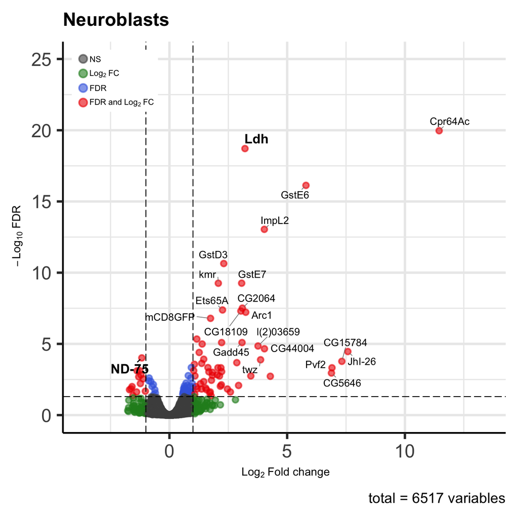

```r
highlighted_cell_type <- "Neuroblasts"

volcano_plot_neuroblasts <- deg_volcano_plot(
    cell_type = highlighted_cell_type,
    results_dir = deg_results_dir,
    plot_dir = deg_plot_dir,
    lfc_threshold = 1.0,
    fdr_threshold = 0.05,
    label_prop = 0.8,
    highlight_genes = c("Ldh", "ND-75"),
    remove_artifacts = TRUE,
    exclude_patterns = gene_patterns_to_exclude
)

volcano_plot_neuroblasts
```

### Significant DEGs in Neuroblasts

**edgeR DEG counts + summary table (Neuroblasts)**

```r
deg_table_data <- deg_results %>%
  filter(is_artifact == FALSE | is.na(is_artifact)) %>%
  filter(FDR < 0.05, abs(logFC) >= 1.0) %>%
  filter(!grepl(exclude_regex, gene)) %>%
  mutate(
    logFC = signif(logFC, 3),
    logCPM = signif(logCPM, 3),
    FDR = signif(FDR, 3)
  ) %>%
  arrange(desc(logFC)) %>%
  dplyr::select(gene, fb_id, logFC, logCPM, FDR)

div(
  style = "margin-bottom: 30px; font-family: sans-serif;",
  reactable(
    deg_table_data,
    pagination = FALSE,
    height = 500,
    searchable = TRUE,
    highlight = TRUE,
    compact = TRUE,
    bordered = TRUE,
    defaultColDef = colDef(align = "center"),
    columns = list(
      gene = flybase_column(deg_table_data),
      fb_id = colDef(show = FALSE),
      logFC = colDef(
        name = "log2 Fold Change",
        cell = function(value) {
          max_abs_val <- max(abs(deg_table_data$logFC))
          width <- paste0((abs(value) / max_abs_val) * 100, "%")
          color <- if (value > 0) "#B2182B" else "#2166AC"

          bar_container <- div(
            style = list(display = "flex", alignItems = "center", width = "120px", height = "18px"),
            # Negative side (Downregulated)
            div(style = list(width = "50%", display = "flex", justifyContent = "flex-end"),
                if (value < 0) div(style = list(background = color, width = width, height = "10px", borderRadius = "2px"))),
            # Center Divider
            div(style = list(width = "1px", height = "100%", background = "#ccc", margin = "0 2px")),
            # Positive side (Upregulated)
            div(style = list(width = "50%", display = "flex", justifyContent = "flex-start"),
                if (value > 0) div(style = list(background = color, width = width, height = "10px", borderRadius = "2px")))
          )

          div(style = list(display = "flex", alignItems = "center"),
              span(style = list(width = "40px", textAlign = "right", marginRight = "10px"), value),
              bar_container)
        }
      ),
      logCPM = colDef(name = "logCPM"),
      FDR = colDef(
        name = "FDR",
        cell = function(value) format(value, scientific = TRUE)
      )
    )
  )
)
```

| Gene | log2 Fold Change | logCPM | FDR |
| --- | --- | --- | --- |
| Cpr64Ac | 11.5 | 5.68 | 1.08e-20 |
| JhI-26 | 7.58 | 1.71 | 3.44e-05 |
| CG15784 | 7.32 | 1.46 | 0.000167 |
| Pvf2 | 6.9 | 1.4 | 0.000476 |
| CG5646 | 6.88 | 1.14 | 0.00111 |
| GstE6 | 5.8 | 4.92 | 7.42e-17 |
| CG18547 | 4.28 | 1.57 | 0.00187 |
| ImpL2 | 4.03 | 4.76 | 9.07e-14 |
| CG44004 | 4.03 | 2.48 | 2.19e-05 |
| twz | 3.87 | 2.23 | 0.00013 |

[output cut: 61 more lines]

## SCENIC analysis on Neuroblasts subset

The SCENIC analysis returns a matrix of regulon activity scores (AUCell) per cell. Statistical testing to identify differentially regulated regulons between Control and ND75-KD neuroblasts is performed using a two-sided Mann-Whitney U test, with the rank-biserial *r* as the effect size (BH-corrected; *r* > 0 = more active in ND75-KD). We also assess the correlation of regulon activity with the expression of the metabolic gene *Ldh*, computed separately within each condition, to identify regulons potentially involved in metabolic regulation; Δρ = ρ<sub>ND75-KD</sub> − ρ<sub>Control</sub> captures condition-specific coupling.

### Differential regulon activity

Regulons whose per-cell AUCell activity differs between Control and ND75-KD neuroblasts, identified by a two-sided Mann-Whitney test on the AUCell scores (BH-corrected, rank-biserial *r* effect size).

#### Top differential regulons

Ranked by |rank-biserial r| (Mann-Whitney effect sizes). A regulon with **r > 0** is more active in ND75-KD cells.

**SCENIC differential-activity results table**

```r
sig_results <- scenic_nb_results_df %>%
    filter(mw_fdr < 0.05)

sig_results_ranked <- sig_results %>%
    arrange(desc(abs(rank_biserial_r))) %>%
    mutate(Rank = row_number()) %>%
    dplyr::select(
        Rank, TF, fb_id,
        rank_biserial_r, cohens_d, NES,
        n_targets, mw_fdr
    )

div(
    style = "margin-bottom: 30px; font-family: sans-serif;",
    reactable(
        sig_results_ranked,
        pagination = FALSE, height = 500,
        searchable = TRUE, highlight = TRUE,
        compact = TRUE, bordered = TRUE,
        defaultColDef = colDef(align = "center"),
        columns = list(
            Rank = colDef(width = 60,
                          style = list(fontWeight = "bold", color = "#555")),
            fb_id = colDef(show = FALSE), # Hide the ID column
            TF   = colDef(
                align = "left",
                style = list(fontStyle = "italic"),
                html = TRUE,  # Ensure HTML processing is ON
                cell = function(value, index) {
                    # Extract directly from the specific row
                    fbid <- sig_results_ranked[index, "fb_id"]
                    if (!is.na(fbid) && fbid != "") {
                        make_flybase_link(fbid, value)
                    } else {
                        value
                    }
                }
            ),
            rank_biserial_r = colDef(
                name = "Rank-Biserial r",
                cell = function(value) {
                    color <- if (value > 0) "#B2182B" else "#2166AC"
                    arrow <- if (value > 0) " ↑" else " ↓"
                    bar_w <- paste0(abs(value) * 100, "%")
                    div(style = list(display = "flex", alignItems = "center", gap = "6px"),
                        div(style = list(width = "80px", height = "12px",
                                         background = "#eee", borderRadius = "2px",
                                         overflow = "hidden", position = "relative"),
                            div(style = list(position  = "absolute",
                                             left      = if (value >= 0) "50%" else "auto",
                                             right     = if (value <  0) "50%" else "auto",
                                             width     = bar_w, height = "100%",
                                             background = color, borderRadius = "2px"))),
                        span(style = list(color = color, fontWeight = "bold",
                                          fontSize = "0.85em", whiteSpace = "nowrap"),
                             paste0(round(value, 3), arrow)))
                }
            ),
            cohens_d  = colDef(name = "Cohen's d",  format = colFormat(digits = 3)),
            NES       = colDef(name = "NES (max)",   format = colFormat(digits = 2)),
            n_targets = colDef(name = "N Targets",   format = colFormat(digits = 0)),
            mw_fdr    = colDef(name = "FDR",
                               cell = function(v) format(v, scientific = TRUE, digits = 3))
        )
    )
)
```

| Rank | TF | Rank-Biserial r | Cohen's d | NES (max) | N Targets | FDR |
| --- | --- | --- | --- | --- | --- | --- |
| 1 | crc | 0.561930870847762 | 1.0929767808734 | 5.96647424369023 | 1043 | 1.88070740931154e-35 |
| 2 | Ets65A | 0.546251763498782 | 1.08927162192134 | 4.59331557840577 | 953 | 9.54668464596596e-34 |
| 3 | E(spl)m3-HLH | 0.524865332820315 | 0.949471782249314 | 6.21412063823208 | 116 | 2.82030760160017e-31 |
| 4 | CG10366 | -0.519799281775042 | -1.0009298915965 | 7.52345803464335 | 1674 | 8.64948418260766e-31 |
| 5 | Pdp1 | 0.492785686802616 | 0.871129081067526 | 4.23290757875938 | 742 | 1.00621376851477e-27 |
| 6 | CG10462 | 0.488392971655765 | 0.862896459516494 | 6.0786990660654 | 927 | 2.64279759127089e-27 |
| 7 | stc | 0.483022316275491 | 0.90890339207425 | 5.01876158816479 | 146 | 9.09265935351656e-27 |
| 8 | cyc | 0.476641657047582 | 0.888110587043244 | 7.08985413298546 | 770 | 4.06668551532001e-26 |
| 9 | gsb | -0.47139925612415 | -0.882626553453617 | 7.72359656003738 | 1953 | 1.35922937360896e-25 |
| 10 | da | 0.469812107220726 | 0.855944946814811 | 4.42702064058491 | 1549 | 1.82156892568204e-25 |

[output cut: 443 more lines]

#### Regulon activity heatmap in Neuroblasts

Per-cell AUCell scores for the top 40 upregulated regulons (ranked by rank-biserial r), with cells grouped by condition. Annotations show the DRA effect size (rank-biserial r) and Ldh Δρ for each regulon.

**Regulon activity heatmap (Neuroblasts)**

[figure not shown]

Figure 2: Heatmap of per-cell regulon AUCell scores for the top 40 upregulated SCENIC regulons in Neuroblasts, ranked by DRA rank-biserial r. Cells are grouped by condition (Control/ND75-KD). Annotations show rank-biserial r effect size and Ldh Δρ per regulon. Colour scale represents z-scored AUCell activity.

```r
# Top 40 upregulated by rank_biserial_r
# Define thresholds and subset
n_top         <- 40
top_tfs_hm    <- head(top_up_regs, n_top)
top_cols_hm   <- tf_to_col[top_tfs_hm]
top_cols_hm   <- top_cols_hm[!is.na(top_cols_hm)]

auc_subset    <- auc_mtx[, top_cols_hm]

# Force ND75-KD to be the top level in the row split
condition_factor <- factor(condition, levels = c("ND75-KD", "Control"))
cell_order       <- order(condition_factor)
auc_ordered      <- auc_subset[cell_order, ]
cond_ordered     <- condition_factor[cell_order]

auc_zscore    <- scale(auc_ordered)
auc_zscore[auc_zscore >  3] <-  3
auc_zscore[auc_zscore < -3] <- -3

ldh_expr      <- target_expr[cell_order]
ldh_scaled    <- scale(ldh_expr)

# Effect sizes
effect_sizes  <- scenic_nb_results_df$rank_biserial_r[
    match(top_tfs_hm, scenic_nb_results_df$TF)
]
ldh_delta_ann <- pmax(
    scenic_nb_results_df$ldh_delta_rho[
        match(top_tfs_hm, scenic_nb_results_df$TF)
    ], 0
)

lgd_param <- list(direction = "horizontal", title_position = "topcenter")

# Condition is a ROW annotation
row_anno_cond <- rowAnnotation(
    Condition = cond_ordered,
    col = list(Condition = c("ND75-KD" = "#EF6548", "Control" = "#4292C6")),
    show_annotation_name = FALSE,
    annotation_name_side = "top",
    annotation_name_rot  = 90,
    annotation_name_gp   = gpar(fontsize = 12, fontface = "bold"),
    simple_anno_size     = unit(0.5, "cm"),
    border = TRUE, show_legend = FALSE
)

# Stats are a BOTTOM annotation
col_anno_stats <- HeatmapAnnotation(
    ` `               = anno_empty(border = FALSE, height = unit(1, "mm")),
    `Rank-biserial r` = effect_sizes,
    `Ldh Δρ`          = ldh_delta_ann,
    col = list(
        `Rank-biserial r` = colorRamp2(c(0, max(effect_sizes, na.rm = TRUE)), c("white", "#B2182B")),
        `Ldh Δρ`          = colorRamp2(c(0, 1), c("white", "#67001F"))
    ),
    annotation_name_side = "left",
    annotation_name_rot  = 0,
    annotation_name_gp   = gpar(fontsize = 10, fontface = "bold"),
    simple_anno_size     = unit(0.4, "cm"),
    border = TRUE,
    gap    = unit(c(0, 2), "mm"),
    annotation_legend_param = list(
        `Rank-biserial r` = lgd_param,
        `Ldh Δρ`          = lgd_param
    )
)

shared_col_fun <- colorRamp2(c(-3, 0, 3), c("#2166AC", "white", "#B2182B"))

# Main Heatmap
ht_main <- Heatmap(
    auc_zscore,
    name              = "Regulon Activity (Z-score)",
    col               = shared_col_fun,
    column_labels     = top_tfs_hm,
    bottom_annotation = col_anno_stats,
    left_annotation   = row_anno_cond,
    cluster_rows      = FALSE,
    row_split         = cond_ordered,
    row_title_side    = "left",
    row_title_rot     = 90,
    cluster_columns   = FALSE,
    show_column_names = TRUE,
    column_names_side = "bottom",
    column_names_rot  = 45, # Keep main regulons at 45
    column_names_gp   = gpar(fontsize = 8, fontface = "italic"),
    border = TRUE, use_raster = TRUE,
    heatmap_legend_param = lgd_param
)

# LDH Heatmap
ht_ldh <- Heatmap(
    matrix(ldh_scaled, ncol = 1),
    name              = "Ldh Expression (Scaled)",
    col               = shared_col_fun,
    cluster_rows      = FALSE,
    column_labels     = paste0(target_gene, " Expr"),
    column_names_side = "bottom",
    column_names_rot  = 90, # Revert LDH label back to 90 degrees
    column_names_gp   = gpar(fontsize = 10, fontface = "bold.italic"),
    width             = unit(1, "cm"),
    border            = TRUE,
    heatmap_legend_param = lgd_param
)

# Combine the regulon and Ldh heatmaps
ht_combined <- ht_main + ht_ldh

draw_regulon_heatmap <- function() {
    draw(ht_combined, ht_gap = unit(2, "mm"),
         heatmap_legend_side = "bottom", annotation_legend_side = "bottom",
         merge_legends = TRUE, legend_gap = unit(40, "mm"),
         padding = unit(c(5, 10, 5, 5), "mm"))
}

invisible(capture.output({
    cairo_pdf(here(output_dir, "SCENIC_Regulon_Heatmap.pdf"), width = 20, height = 10)
    draw_regulon_heatmap()
    invisible(dev.off())

    png(here(output_dir, "SCENIC_Regulon_Heatmap.png"),
        width = 16, height = 10, units = "in", res = 300)
    draw_regulon_heatmap()
    invisible(dev.off())
}))

# Inline display
draw_regulon_heatmap()
```

#### Per-cell regulon activity for the top differential regulons

Per-cell AUCell activity for the five regulons most increased and the five most decreased in ND75-KD neuroblasts, ranked by differential regulon activity (rank-biserial *r*).

**Per-cell regulon activity violins (top differential regulons)**

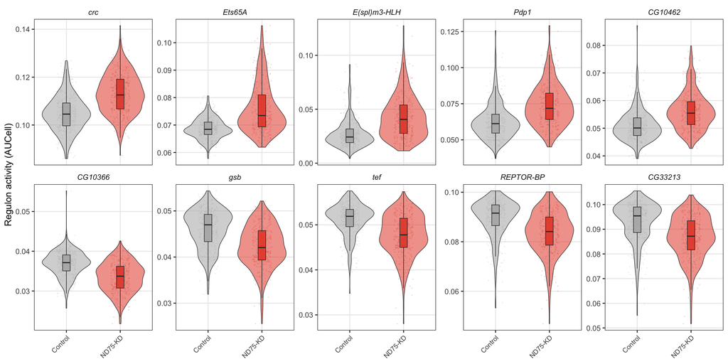

Figure 3: Per-cell pySCENIC AUCell activity of the five most up- and five most down-regulated regulons in Neuroblasts (ranked by differential regulon activity, rank-biserial r), split by condition. Points are individual cells; violin width is the activity distribution; embedded boxplots show the median and interquartile range. Top row: regulons upregulated in ND75-KD; bottom row: downregulated.

```r
n_each <- 5

reg_up <- scenic_nb_results_df %>%
    filter(rank_biserial_r > 0) %>%
    arrange(desc(rank_biserial_r)) %>%
    head(n_each) %>%
    transmute(TF, direction = "Upregulated in ND75-KD")

reg_dn <- scenic_nb_results_df %>%
    filter(rank_biserial_r < 0) %>%
    arrange(rank_biserial_r) %>%
    head(n_each) %>%
    transmute(TF, direction = "Downregulated in ND75-KD")

reg_sel  <- bind_rows(reg_up, reg_dn)
reg_cols <- tf_to_col[reg_sel$TF]              # handles TFs with parens in the name
reg_sel  <- reg_sel[!is.na(reg_cols), , drop = FALSE]
reg_cols <- reg_cols[!is.na(reg_cols)]

reg_activity_df <- as.data.frame(auc_mtx[, reg_cols, drop = FALSE])
colnames(reg_activity_df) <- reg_sel$TF
reg_activity_df$condition <- condition        # aligned to rownames(auc_mtx)

reg_activity_long <- reg_activity_df %>%
    tidyr::pivot_longer(-condition, names_to = "TF", values_to = "auc") %>%
    left_join(reg_sel, by = "TF") %>%
    mutate(
        TF        = factor(TF, levels = reg_sel$TF),      # up first, then down
        condition = factor(condition, levels = c("Control", "ND75-KD"))
    )

cond_cols <- c("Control" = "grey70", "ND75-KD" = "#E64B35")

p_regulon_violins <- ggplot(
    reg_activity_long, aes(x = condition, y = auc, fill = condition)
) +
    geom_jitter(aes(colour = condition), width = 0.18, size = 0.15,
                alpha = 0.12, show.legend = FALSE) +
    geom_violin(scale = "width", alpha = 0.55, linewidth = 0.3, colour = "grey30") +
    geom_boxplot(width = 0.14, outlier.shape = NA, alpha = 0.9, linewidth = 0.3) +
    scale_fill_manual(values = cond_cols) +
    scale_colour_manual(values = cond_cols) +
    facet_wrap(~ TF, scales = "free_y", ncol = n_each) +
    labs(x = NULL, y = "Regulon activity (AUCell)") +
    theme_bw() +
    theme(
        legend.position  = "none",
        strip.background = element_blank(),
        strip.text       = element_text(face = "italic", size = 9),
        axis.text.x      = element_text(angle = 45, hjust = 1, size = 8),
        panel.grid.minor = element_blank()
    )

ggsave(
    file.path(output_dir, "regulon_activity_violins_top_differential.pdf"),
    p_regulon_violins, width = 12, height = 6
)

p_regulon_violins
```

### Regulon activity vs Ldh coupling

Cross-referencing each regulon’s differential activity with how tightly its activity tracks *Ldh* expression. *Ldh* coupling is the Spearman ρ between a regulon’s AUCell activity and *Ldh*, computed within each condition; Δρ = ρ<sub>ND75-KD</sub> − ρ<sub>Control</sub> captures coupling that appears specifically in ND75-KD. Regulons that are both more active and more *Ldh*-coupled in ND75-KD are the candidate drivers of the metabolic response.

#### TF differential activity vs Ldh co-regulation

Each regulon is plotted by its differential activity (x, rank-biserial *r*) against its condition-specific *Ldh* coupling (y, Δρ = ρ<sub>ND75-KD</sub> − ρ<sub>Control</sub>); colour is the overall Spearman ρ with *Ldh*, and significant DRA regulons (FDR < 0.05) are outlined.

**SCENIC TF activity vs Ldh co-regulation scatter**

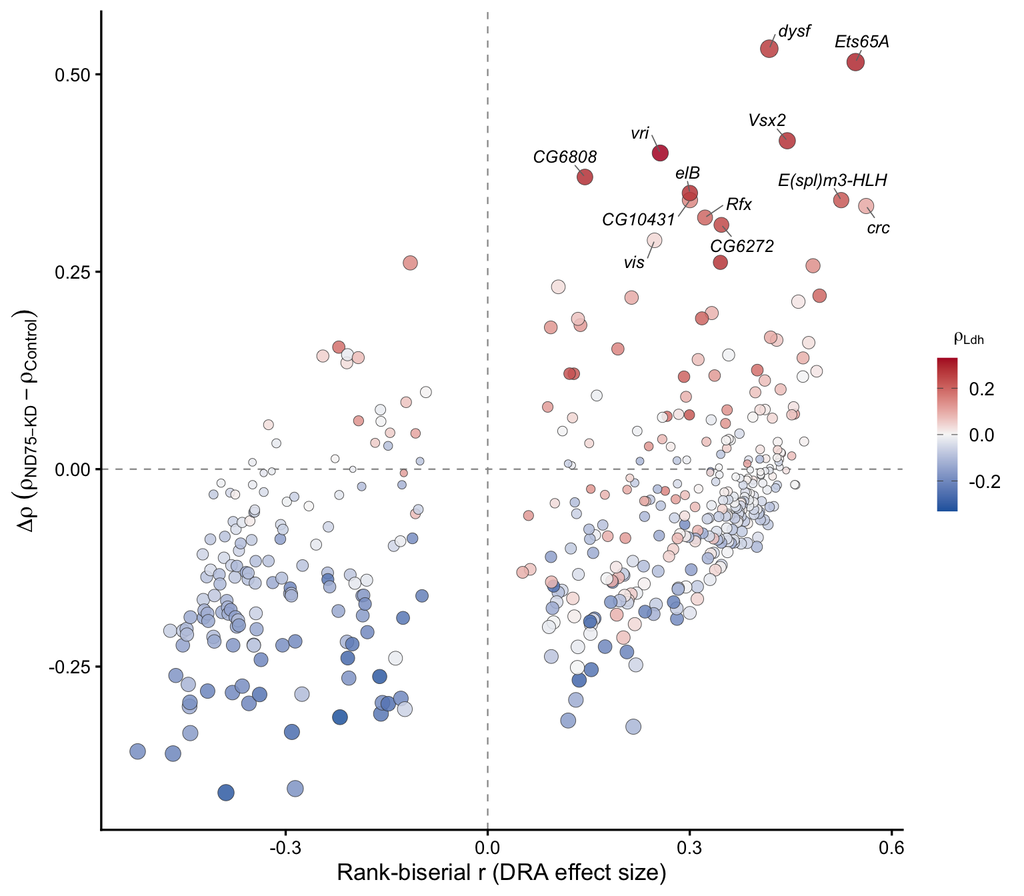

Figure 4: Scatter plot of TF regulon differential activity (x-axis, rank-biserial r from Mann-Whitney test) versus Ldh co-regulation (y-axis, Δρ = ρ<sub>ND75-KD</sub> − ρ<sub>Control</sub>). Each point represents a regulon with the colour depicting overall Spearman ρ with Ldh and size representing |Δρ|. Filled, outlined points are statistically significant (DRA FDR < 0.05). Top upregulated TFs most strongly coupled to Ldh are labelled.

```r
n_label <- 12

scatter_df <- scenic_nb_results_df %>%
    filter(!is.na(ldh_delta_rho), !is.na(rank_biserial_r), !is.na(ldh_rho_overall)) %>%
    mutate(
        dra_sig_up = mw_fdr < 0.05 & rank_biserial_r > 0,
        dra_sig_dn = mw_fdr < 0.05 & rank_biserial_r < 0,
        do_label   = dra_sig_up & rank(-ldh_delta_rho) <= n_label
    )

cor_limit <- max(abs(scatter_df$ldh_rho_overall), na.rm = TRUE)

scenic_scatter_plot <- ggplot(scatter_df, aes(x = rank_biserial_r, y = ldh_delta_rho)) +
    geom_hline(yintercept = 0, linetype = "dashed",
               color = "grey60", linewidth = 0.4) +
    geom_vline(xintercept = 0, linetype = "dashed",
               color = "grey60", linewidth = 0.4) +
    geom_point(
        data = filter(scatter_df, !dra_sig_up & !dra_sig_dn),
        aes(fill = ldh_rho_overall),
        shape = 21, color = NA, size = 1.8, alpha = 0.25
    ) +
    geom_point(
        data = filter(scatter_df, dra_sig_up | dra_sig_dn),
        aes(fill = ldh_rho_overall, size = abs(ldh_delta_rho)),
        shape = 21, color = "grey25", stroke = 0.25, alpha = 0.85
    ) +
    ggrepel::geom_text_repel(
        data         = filter(scatter_df, do_label),
        aes(label    = TF),
        fontface     = "italic",
        size         = 3.4,
        max.overlaps = 20,
        box.padding  = 0.5,
        segment.color = "grey45",
        segment.size  = 0.3,
        min.segment.length = 0.2,
        force = 1.5
    ) +
    scale_fill_gradientn(
        colours = c("#2166AC", "#F7F7F7", "#B2182B"),
        limits  = c(-cor_limit, cor_limit),
        name    = expression(rho[Ldh]),
        guide   = guide_colorbar(
            barwidth     = 0.8,
            barheight    = 6,
            ticks.colour = "grey30",
            title.hjust  = 0.5
        )
    ) +
    scale_size_continuous(range = c(1.5, 4.5), guide = "none") +
    labs(
        x = "Rank-biserial r (DRA effect size)",
        y = expression(Delta*rho~(rho[ND75-KD]-rho[Control]))
    ) +
    theme_classic(base_size = 13) +
    theme(
        legend.position = "right",
        legend.title    = element_text(size = 10, hjust = 0.5),
        plot.title      = element_text(face = "bold"),
        plot.subtitle   = element_text(size = 9, color = "grey40")
    )

scenic_scatter_plot

ggsave(
    filename = here(output_dir, "SCENIC_TF_Activity_vs_Ldh_Correlation_Scatter.png"),
    plot = scenic_scatter_plot,
    width = 8, height = 7, dpi = 300
)

ggsave(
    filename = here(output_dir, "SCENIC_TF_Activity_vs_Ldh_Correlation_Scatter.pdf"),
    plot = scenic_scatter_plot,
    width = 8, height = 7
)
```

#### Regulon activity correlated with *Ldh* expression

**Ldh-coupled regulon ranking table**

```r
metabolic_ranked <- sig_results %>%
    filter(!is.na(ldh_rho_overall)) %>%
    arrange(desc(ldh_delta_rho)) %>%
    mutate(
        Rank            = row_number(),
        ldh_rho_overall = signif(ldh_rho_overall, 3),
        ldh_delta_rho   = signif(ldh_delta_rho,   3),
        rank_biserial_r = signif(rank_biserial_r,  3)
    ) %>%
    dplyr::select(
        Rank, TF, fb_id,
        ldh_rho_overall, ldh_rho_Control, ldh_rho_ND75_KD,
        ldh_delta_rho, ldh_fdr
    )

div(
    style = "font-family: sans-serif;",
    reactable(
        metabolic_ranked,
        pagination = FALSE, height = 500,
        searchable = TRUE, highlight = TRUE,
        compact = TRUE, bordered = TRUE,
        defaultColDef = colDef(align = "center"),
        columns = list(
            Rank = colDef(width = 60,
                          style = list(fontWeight = "bold", color = "#555")),
            fb_id = colDef(show = FALSE), # Hide the ID column
            TF   = colDef(
                align = "left",
                style = list(fontStyle = "italic"),
                html = TRUE,
                cell = function(value, index) {
                    fbid <- metabolic_ranked[index, "fb_id"]
                    if (!is.na(fbid) && fbid != "") {
                        make_flybase_link(fbid, value)
                    } else {
                        value
                    }
                }
            ),
            ldh_rho_overall     = colDef(name = "ρ Overall",     format = colFormat(digits = 3)),
            ldh_rho_Control     = colDef(name = "ρ Control",     format = colFormat(digits = 3)),
            ldh_rho_ND75_KD = colDef(name = "ρ ND75-KD", format = colFormat(digits = 3)),
            ldh_delta_rho = colDef(
                name = "Δρ (Dysf − Ctrl)",
                cell = function(value) {
                    color <- if (value > 0) "#67001F" else "#2166AC"
                    bar_w <- paste0(min(abs(value) / 0.5, 1) * 100, "%")
                    div(style = list(display = "flex", alignItems = "center", gap = "6px"),
                        div(style = list(width = "70px", height = "12px",
                                         background = "#eee", borderRadius = "2px",
                                         overflow = "hidden", position = "relative"),
                            div(style = list(position  = "absolute",
                                             left      = if (value >= 0) "50%" else "auto",
                                             right     = if (value <  0) "50%" else "auto",
                                             width     = bar_w, height = "100%",
                                             background = color, borderRadius = "2px"))),
                        span(style = list(color = color, fontWeight = "bold",
                                          fontSize = "0.85em"), round(value, 3)))
                }
            ),
            ldh_fdr = colDef(name = "Ldh FDR",
                             cell = function(v) format(v, scientific = TRUE, digits = 3))
        )
    )
)
```

| Rank | TF | ρ Overall | ρ Control | ρ ND75-KD | Δρ (Dysf − Ctrl) | Ldh FDR |
| --- | --- | --- | --- | --- | --- | --- |
| 1 | dysf | 0.26 | -0.0483027692890526 | 0.484101700290331 | 0.532 | 6.4398561962128e-11 |
| 2 | Ets65A | 0.291 | 0.00745299831514407 | 0.522928749606473 | 0.515 | 1.88179086621544e-13 |
| 3 | Vsx2 | 0.277 | 0.0419581609705214 | 0.457822361568694 | 0.416 | 3.02483903006443e-12 |
| 4 | vri | 0.33 | 0.10841386269452 | 0.508739543693037 | 0.4 | 9.42525020846892e-17 |
| 5 | CG6808 | 0.281 | 0.072745921314496 | 0.442697758363394 | 0.37 | 1.6534694712271e-12 |
| 6 | elB | 0.278 | 0.0727374473495019 | 0.422355447525775 | 0.35 | 2.6517968652554e-12 |
| 7 | CG10431 | 0.146 | -0.0650584279335673 | 0.275650609990673 | 0.341 | 0.000528282997461732 |
| 8 | E(spl)m3-HLH | 0.218 | -0.00584528261178319 | 0.334808798787525 | 0.341 | 7.18025473255253e-08 |
| 9 | crc | 0.101 | -0.147608142334843 | 0.185615543922567 | 0.333 | 0.0219784977679282 |
| 10 | Rfx | 0.196 | -0.00507325990614133 | 0.31357552650766 | 0.319 | 1.38838624923133e-06 |

[output cut: 443 more lines]

## hdWGCNA analysis

hdWGCNA (hierarchical dense Weighted Gene Co-expression Network Analysis) identifies modules of co-expressed genes using metacell-aggregated expression profiles. Each module is summarised by its module eigengene (ME), the first principal component of its member genes’ expression. Module-trait correlation tests whether a module’s eigengene is significantly associated with condition (Control vs ND75-KD) using Spearman correlation. Modules with a positive, FDR-significant correlation are upregulated in ND75-KD neuroblasts. Hub genes are the most highly connected members within each module (highest kME), and serve as proxies for the module’s biological identity.

**hdWGCNA: modules, eigengene–condition stats, hub genes**

```r
# Module names (NB_M1..NB_Mn) are already set by hdWGCNA/00_hdWGCNA_analysis.R.
# Subset to Neuroblasts for downstream analysis
hdWGCNA_nb <- subset(hdWGCNA_results, subset = cell_type_manual == "Neuroblasts")
# Recalculate module eigengenes for Neuroblasts subset
nb_modules <- GetModules(hdWGCNA_results)
MEs_all <- GetMEs(hdWGCNA_results)
MEs_nb <- MEs_all[colnames(hdWGCNA_nb), ]
all_modules <- setdiff(colnames(MEs_nb), "grey")

hdWGCNA_nb$condition_num <- as.numeric(hdWGCNA_nb$condition == "ND75-KD")

# Re-establish the internal expression pointers for the Neuroblast subset
# This ensures internal hdWGCNA indices match the current subsetted cells
hdWGCNA_nb <- SetDatExpr(
    hdWGCNA_nb,
    group_name = "Neuroblasts",
    group.by = "cell_type_manual",
    use_metacells = TRUE,
    assay = "RNA"
)

# Re-calculate Module Eigengenes for this specific subset
# This forces the internal ME matrix to match the current row (cell) count
invisible(capture.output(hdWGCNA_nb <- ModuleEigengenes(
    hdWGCNA_nb,
    assay = "RNA"
)))

# 4. Run the correlation
hdWGCNA_nb <- ModuleTraitCorrelation(
    hdWGCNA_nb,
    traits = "condition_num",
    group.by = "cell_type_manual",
    features = "MEs"
)

# Extract results for your summary tables
nb_cor_results <- GetModuleTraitCorrelation(hdWGCNA_nb)

nb_cor_vec <- nb_cor_results$cor$Neuroblasts
nb_fdr_vec <- nb_cor_results$fdr$Neuroblasts

# Create the clean correlation data frame
cor_df <- data.frame(
    module = names(nb_cor_vec),
    correlation = as.numeric(nb_cor_vec),
    fdr_cor = as.numeric(nb_fdr_vec),
    stringsAsFactors = FALSE
)

# Identify Hub Genes and Module Stats
hub_genes_list <- sapply(all_modules, function(mod) {
  kme_col <- paste0("kME_", mod)

  # Check if column exists to avoid errors
  if(!kme_col %in% colnames(nb_modules)) return(NA)

  nb_modules %>%
    filter(module == mod) %>%
    arrange(desc(.data[[kme_col]])) %>%
    head(5) %>%
    pull(gene_name) %>%
    paste(collapse = ", ")
})

# Calculate Stats
me_stats <- lapply(all_modules, function(mod) {
  me_vals <- MEs_nb[[mod]]
  condition <- hdWGCNA_nb$condition

  ctrl <- me_vals[condition == "Control"]
  nd75_kd <- me_vals[condition == "ND75-KD"]

  test <- wilcox.test(nd75_kd, ctrl)
  cohens_d <- (mean(nd75_kd) - mean(ctrl)) / sqrt((var(ctrl) + var(nd75_kd)) / 2)

  data.frame(
    module = mod,
    n_control = length(ctrl),
    n_ND75_KD = length(nd75_kd),
    mean_control = mean(ctrl),
    mean_ND75_KD = mean(nd75_kd),
    delta = mean(nd75_kd) - mean(ctrl),
    cohens_d = cohens_d,
    p_value = test$p.value
  )
}) %>%
  bind_rows() %>%
  mutate(
    fdr = p.adjust(p_value, method = "BH"),
    hub_genes = hub_genes_list[module]
  ) %>%
  arrange(desc(cohens_d))


# Add correlation results
me_stats <- me_stats %>%
    left_join(cor_df, by = "module")

sig_mods <- me_stats %>%
    filter(fdr_cor < 0.05) %>%
    pull(module)
```

### Module–condition association

Module-trait correlation tests whether a module’s eigengene is significantly associated with condition (Control vs ND75-KD) using Spearman correlation.

#### Module–trait correlation (Figure 2E)

Correlation coefficient (*r*) between each module eigengene and condition; dot size = FDR; modules labelled by GO-derived functional identity and top-5 hub genes. Positive correlation indicates upregulated in ND75-KD.

**Module–condition correlation panel (Figure 2E)**

[figure not shown]

Figure 5: Module-condition correlation plot for hdWGCNA Neuroblast modules. Left panel: GO-derived functional label and the five highest-kME hub genes per module (Ldh bolded where present). Right panel: Spearman correlation of each module eigengene with condition (positive = upregulated in ND-75 KD); point size = -log10(FDR); faded = non-significant (FDR >= 0.05).

```r
# GO-derived functional labels for the Neuroblast modules, taken from the
# canonical hdWGCNA/resources/hdWGCNA_module_manuscript_labels.csv loaded in
# load-data (module_labels_canonical). The "(NB_Mx)" suffix keys each label to
# its module within the panel.
module_labels <- setNames(
  sprintf("%s (%s)", module_labels_canonical, names(module_labels_canonical)),
  names(module_labels_canonical)
)

# Plotmath label for the top-5 hub genes; bold Ldh and move it first where present.
make_hub_plotmath <- function(hub_str) {
  genes <- trimws(strsplit(hub_str, ",", fixed = TRUE)[[1]])
  genes <- genes[nzchar(genes)]
  if ("Ldh" %in% genes) {
    others <- paste(setdiff(genes, "Ldh"), collapse = " · ")
    sprintf("paste('Top hubs: ', bold('Ldh'), ' · %s')", others)
  } else {
    sprintf("'Top hubs: %s'", paste(genes, collapse = " · "))
  }
}

# Build plot data directly from the module statistics computed above
# (me_stats: correlation + fdr_cor from ModuleTraitCorrelation; hub_genes from
# hub_genes_list). Rows are ordered by ascending correlation.
fig2e_module_colors <- c(
  NB_M1  = "#1f77b4", NB_M2  = "#ff7f0e", NB_M3  = "#2ca02c",
  NB_M4  = "#9467bd", NB_M5  = "#8c564b", NB_M6  = "#e377c2",
  NB_M7  = "#bcbd22", NB_M8  = "#17becf", NB_M9  = "#e31a1c",
  NB_M10 = "#aec7e8", NB_M11 = "#98df8a"
)

me_plot_data <- me_stats %>%
  dplyr::arrange(correlation) %>%
  dplyr::mutate(
    row              = dplyr::row_number(),
    fdr_cor_plot     = pmax(fdr_cor, 1e-300),   # floor to avoid -log10(0) = Inf
    is_sig           = ifelse(fdr_cor < 0.05, "Significant", "Non-Significant"),
    cor_label        = sprintf("%.2f", correlation),
    functional_label = module_labels[module],
    hub_plotmath     = vapply(hub_genes, make_hub_plotmath, character(1))
  )

y_lims <- c(0.4, nrow(me_plot_data) + 0.6)

label_panel <- ggplot(me_plot_data, aes(y = row)) +
  geom_text(aes(x = 1, label = functional_label),
            hjust = 1, nudge_y = 0.16, size = 4.6, colour = "#111111") +
  geom_text(aes(x = 1, label = hub_plotmath),
            hjust = 1, nudge_y = -0.18, size = 4.3, colour = "#555555", parse = TRUE) +
  coord_cartesian(xlim = c(0, 1), ylim = y_lims, clip = "off") +
  theme_void() +
  theme(plot.margin = margin(6, 12, 6, 6))

lollipop_panel <- ggplot(me_plot_data, aes(x = correlation, y = row)) +
  geom_hline(yintercept = me_plot_data$row, colour = "grey95", linewidth = 0.5) +
  geom_vline(xintercept = 0, colour = "grey60", linetype = "dashed", linewidth = 0.8) +
  geom_segment(aes(x = 0, xend = correlation, yend = row, colour = module, alpha = is_sig),
               linewidth = 1.8) +
  geom_point(aes(fill = module, size = -log10(fdr_cor_plot), alpha = is_sig),
             shape = 21, colour = "white", stroke = 1.2) +
  geom_text(aes(label = cor_label, hjust = ifelse(correlation > 0, -0.8, 1.8)),
            size = 3.5, colour = "black") +
  scale_x_continuous(expand = expansion(mult = 0.15)) +
  scale_y_continuous(limits = y_lims, breaks = NULL, expand = c(0, 0)) +
  scale_alpha_manual(values = c(Significant = 1, `Non-Significant` = 0.3), guide = "none") +
  scale_colour_manual(values = fig2e_module_colors, guide = "none") +
  scale_fill_manual(values = fig2e_module_colors, guide = "none") +
  scale_size_continuous(
    name = "FDR", range = c(4, 14),
    breaks = c(1.3, 10, 50), labels = c("0.05", "< 1e-10", "< 1e-50"),
    guide = guide_legend(
      direction = "vertical", title.position = "top",
      override.aes = list(fill = "grey80", colour = "white", alpha = 1)
    )
  ) +
  labs(x = "Module correlation with ND-75 KD (r)", y = NULL) +
  theme_minimal(base_size = 14) +
  theme(
    axis.line.x = element_line(colour = "black", linewidth = 0.8),
    axis.text.y = element_blank(),
    panel.grid   = element_blank(),
    legend.position = "right",
    legend.text  = element_text(size = 9),
    legend.title = element_text(size = 10),
    plot.margin  = margin(6, 6, 6, 0)
  )

p_mod_cor_lollipop <- label_panel + lollipop_panel +
  patchwork::plot_layout(widths = c(1, 1))

ggsave(
  filename = here(output_dir, "hdWGCNA_Module_Correlation_Lollipop_Metacell_FDR_with_Hubs.png"),
  plot = p_mod_cor_lollipop,
  width = 15, height = 10, dpi = 300, bg = "white"
)

ggsave(
  filename = here(output_dir, "hdWGCNA_Module_Correlation_Lollipop_Metacell_FDR_with_Hubs.pdf"),
  plot = p_mod_cor_lollipop,
  width = 15, height = 10, bg = "white"
)

p_mod_cor_lollipop
```

#### Network module statistics

Per-module association with condition: the Spearman correlation of each module eigengene with ND75-KD (positive = upregulated), its Cohen’s *d*, the BH-corrected FDR, the eigengene mean difference (delta), and the five highest-kME hub genes. Modules with FDR < 0.05 are treated as ND75-KD-associated downstream.

**Module–condition statistics table**

```r
div(
  style = "margin-bottom: 30px; font-family: sans-serif;",
  reactable(
    me_stats %>% dplyr::select(module, correlation, cohens_d, fdr_cor, delta, hub_genes),
    pagination = FALSE,
    searchable = TRUE,
    compact = TRUE,
    highlight = TRUE,
    bordered = TRUE,
    defaultColDef = colDef(align = "center"),
    columns = list(
      module = colDef(name = "Module", width = 100),
      correlation = colDef(
        name = "Correlation (r)",
        width = 150,
        format = colFormat(digits = 3),
        style = function(value) {
          # Diverging Color Palette: Red (Up), Blue (Down)
          color <- if (value > 0.3) "#f4cccc" else if (value < -0.3) "#cfe2f3" else "#ffffff"
          list(background = color)
        }
      ),
      cohens_d = colDef(
        name = "Cohen's d",
        width = 100,
        format = colFormat(digits = 3),
        style = function(value) {
          # Diverging Color Palette: Red (Up), Blue (Down)
          color <- if (value > 0.3) "#f4cccc" else if (value < -0.3) "#cfe2f3" else "#ffffff"
          list(background = color)
        }
      ),
      fdr_cor = colDef(
        name = "FDR",
        width = 100,
        cell = function(value) format(value, scientific = TRUE, digits = 3),
        style = function(value) {
            if (value < 0.05) list(color = "#333") else list(color = "#999")
        }
      ),
      delta = colDef(
        name = "Delta",
        width = 100,
        format = colFormat(digits = 3),
        style = function(value) {
          if (value > 0) list(color = "#B2182B") else if (value < 0) list(color = "#2166AC") else list()
        }
      ),
      hub_genes = colDef(
        name = "Top 5 Hub Genes",
        width = 400,
        align = "left",
        style = list(fontSize = "0.9em", color = "#555")
      )
    )
  )
)
```

| Module | Correlation (r) | Cohen's d | FDR | Delta | Top 5 Hub Genes |
| --- | --- | --- | --- | --- | --- |
| NB_M7 | 0.451745596968599 | 0.882977469326325 | 0 | 0.992980808816989 | chrb, scyl, Imp, Msp300, rin |
| NB_M5 | 0.363386520985357 | 0.768667925429004 | 0 | 2.038990201168 | kis, CG42232, spen, dom, nej |
| NB_M6 | 0.27796249815535 | 0.590321024726662 | 1.42885703269258e-13 | 1.24332965633904 | Tet, hdc, ct, sbb, lola |
| NB_M9 | 0.242682761875745 | 0.48075544095983 | 1.35892364028223e-10 | 0.604512946725502 | Ldh, kmr, Ets65A, Hex-A, Pdp1 |
| NB_M3 | 0.0601086300098659 | 0.110412172183655 | 0.151654361047102 | 0.231797760984298 | RpL19, RpL27A, RpL18A, RpS26, RpS16 |
| NB_M4 | 0.0320921216306098 | 0.0732149032102564 | 0.450864455992196 | 0.156330899119952 | Rdl, nrv3, Sh, Ggamma30A, slo |
| NB_M11 | 0.0310413227057117 | 0.0290497670385284 | 0.450864455992196 | 0.0709777204840911 | hoip, Nph, RpLP0-like, CG11267, Hsp83 |
| NB_M10 | -0.00163668471448467 | -0.0891473969098741 | 0.965349512330626 | -0.150535177950061 | mt:CoII, mt:CoIII, mt:CoI, mt:Cyt-b, mt:ATPase6 |
| NB_M8 | -0.126168917105786 | -0.268820733426171 | 0.00121476914920371 | -0.425974760493077 | HmgZ, Bacc, CG1910, smt3, CNBP |
| NB_M1 | -0.157748197528778 | -0.326726406305843 | 4.61128049001521e-05 | -1.32799234659132 | eEF1delta, ATPsynC, Fkbp12, ATPsynO, ATPsyngamma |

[output cut: 1 more lines]

**Module–condition statistics table**

```r
# Select top modules for downstream plots
nb_top_modules <- me_stats %>%
  filter(fdr < 0.05, abs(cohens_d) > 0.3) %>%
  head(6) %>%
  pull(module)
```

### Module functional identities

The GO functional label for each module come from GO enrichment of the top-50 hub genes, manually refined in `hdWGCNA/01_GO_enrichment.R`.

**Module functional identities**

```r
# The per-module top GO terms / FDR / gene counts
# live in hdWGCNA/01_GO_enrichment.R and its
# label_review/GO_top_terms_per_module.csv output
go_summary_data <- module_labels_tbl %>%
  dplyr::transmute(
    Module = module,
    Functional_Label = label,
    .ord = suppressWarnings(as.integer(sub("^NB_M", "", module)))
  ) %>%
  dplyr::arrange(.ord) %>%
  dplyr::select(-.ord)

# Render the reactable
div(
  style = "margin-bottom: 30px; font-family: sans-serif;",
  reactable(
    go_summary_data,
    searchable = TRUE,
    compact = TRUE,
    bordered = TRUE,
    highlight = TRUE,
    defaultColDef = colDef(headerStyle = list(background = "#f7f7f8")),
    columns = list(
      Module = colDef(width = 100, style = list(fontWeight = "bold")),
      Functional_Label = colDef(name = "Functional Identity", align = "left", style = list(color = "#005b96", fontWeight = "bold"))
    )
  )
)
```

| Module | Functional Identity |
| --- | --- |
| NB_M1 | Mitochondrial ATP synthesis |
| NB_M2 | Protein degradation & Chromatin |
| NB_M3 | Cytoplasmic translation |
| NB_M4 | Synaptic signalling & Ion transport |
| NB_M5 | Chromatin remodelling & Gene silencing |
| NB_M6 | Transcriptional repression |
| NB_M7 | Stress response & Growth signalling |
| NB_M8 | Epigenetic silencing & Chromatin |
| NB_M9 | Mitochondrial biogenesis & NAD/carbohydrate metabolism |
| NB_M10 | Mitochondrial OxPhos core subunits |

[output cut: 1 more lines]

### Hub genes

The 10 highest-kME genes per module. kME (module eigengene connectivity) is how strongly a gene co-expresses with its module; genes are ordered by decreasing kME within each module.

**Hub-gene kME lollipop**

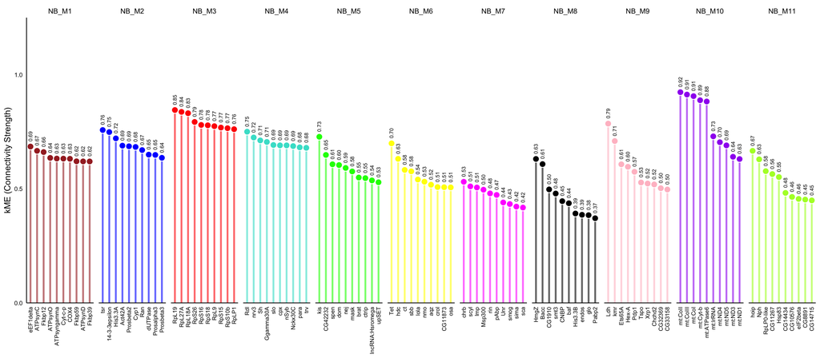

Figure 6: Hub gene connectivity (kME) for the top 10 genes in each hdWGCNA module. Each lollipop represents one gene; kME (module eigengene connectivity) measures how strongly a gene is co-expressed with its module. Genes are ranked left-to-right by decreasing kME within each module.

```r
# Map module names to hex colors
invisible(capture.output(
  mod_colors <- GetModules(hdWGCNA_nb) %>%
    dplyr::select(module, color) %>%
    distinct() %>%
    tibble::deframe()
))

# Prepare data
hub_data <- nb_modules %>%
  filter(module != "grey") %>%
  rename(gene_symbol = any_of(c("gene_name", "gene", "symbol"))) %>%
  dplyr::select(gene_symbol, module, starts_with("kME_")) %>%
  pivot_longer(cols = starts_with("kME_"), names_to = "kME_mod", values_to = "kME") %>%
  mutate(kME_mod = gsub("kME_", "", kME_mod)) %>%
  filter(module == kME_mod) %>%
  group_by(module) %>%
  arrange(desc(kME)) %>%
  slice_head(n = 10) %>%
  ungroup()

# Generate the Refined Plot
p_kME_lollipop <- ggplot(
  hub_data, aes(x = reorder(gene_symbol, -kME), y = kME)) +
  # Lollipop stems
  geom_segment(aes(xend = reorder(gene_symbol, -kME), y = 0, yend = kME, color = module),
               linewidth = 1.2, alpha = 0.6) +

  # Lollipop heads
  geom_point(aes(fill = module), shape = 21, size = 3.8, color = "white", stroke = 0.8) +

  # kME value labels
  geom_text(aes(label = sprintf("%.2f", kME)),
            angle = 90, hjust = -0.5, size = 2.6, color = "black",
            fontface = "plain") +

  # Standardized 0-1 scale
  scale_y_continuous(limits = c(0, 1.25), breaks = seq(0, 1, 0.5), expand = c(0, 0)) +

  scale_fill_manual(values = mod_colors) +
  scale_color_manual(values = mod_colors) +

  facet_wrap(~module, nrow = 1, scales = "free_x") +

  labs(x = NULL, y = "kME (Connectivity Strength)") +

  theme_minimal(base_size = 12) +
  theme(
    legend.position = "none",
    plot.title = element_text(face = "plain"),
    axis.text.x = element_text(angle = 90, hjust = 1, vjust = 0.5, size = 8, color = "black", face = "plain"),
    axis.text.y = element_text(size = 8.5, color = "black", face = "plain"),

    # REMOVE FACET LABEL BORDERS: Set color to NA
    strip.background = element_rect(fill = "white", color = NA),
    strip.text = element_text(size = 10, face = "plain", color = "black"),

    panel.grid.major = element_blank(),
    panel.grid.minor = element_blank(),
    panel.border = element_blank(),

    # Structural axis lines
    axis.line.y = element_line(color = "black", linewidth = 0.5),
    axis.line.x = element_line(color = "black", linewidth = 0.5),

    # SLIGHTLY REDUCE PANEL SPACING: Tuned to 0.8
    panel.spacing.x = unit(0.5, "lines")
  )

ggsave(
  filename = here(output_dir, "hdWGCNA_Module_Hub_Genes_kME_Lollipop_Plot.pdf"),
  plot = p_kME_lollipop,
  width = 20,
  height = 6
)
ggsave(
  filename = here(output_dir, "hdWGCNA_Module_Hub_Genes_kME_Lollipop_Plot.png"),
  plot = p_kME_lollipop,
  width = 20,
  height = 6,
  dpi = 600
)

p_kME_lollipop
```

### Hub-gene network

Global hub-gene connectivity (Kamada-Kawai layout) with the NB_M9 (Ldh) module highlighted and *Ldh* labelled in bold.

**Hub-gene network centred on Ldh**

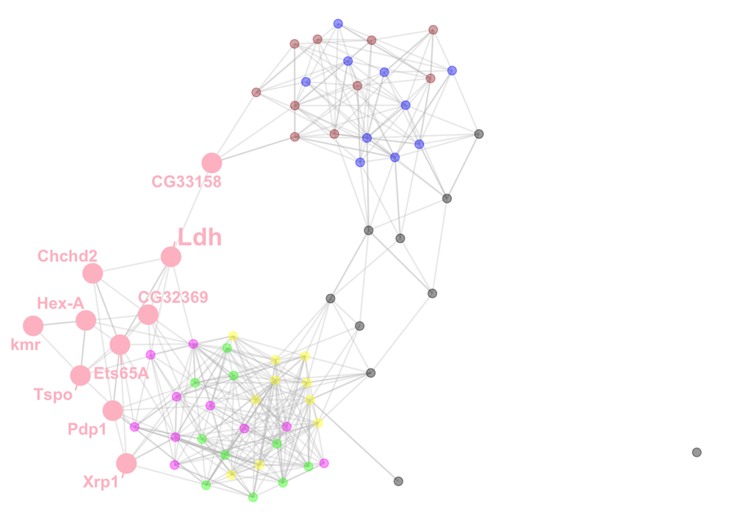

Figure 7: Global hub-gene connectivity (Kamada-Kawai layout). Nodes are hub genes coloured by module; the NB_M9 (Ldh) module is enlarged and its genes labelled, with Ldh in larger bold in the same module colour. Deterministic (seeded edge sub-sampling, layout and ggrepel placement).

```r
options(future.globals.maxSize = 2000 * 1024^2)
future::plan("sequential")   # sequential: avoids parallel overhead for the graph build

# 1. Build the tidygraph object (bridge edges intact). capture.output() mutes
# HubGeneNetworkPlot()'s side-effect print of the module-colour vector.
# HubGeneNetworkPlot() sub-samples edges (edge_prop) — seed it for a stable graph.
set.seed(GLOBAL_SEED)
invisible(capture.output(
  net_graph <- HubGeneNetworkPlot(
    hdWGCNA_nb,
    mods = sig_mods,
    n_hubs = 10,
    n_other = 0,
    edge_prop = 0.25,      # 25% keeps inter-module connections alive
    return_graph = TRUE
  )
))
graph_data <- as_tbl_graph(net_graph)

focal_module_name <- "NB_M9"

# 2. Kamada-Kawai layout — seed it so the initialisation (and thus the final
# coordinates) is reproducible.
set.seed(GLOBAL_SEED)
focal_layout <- ggraph::create_layout(graph_data, layout = "kk")

focal_plot_kk <- ggraph(focal_layout) +
  geom_edge_link(color = "grey75", alpha = 0.3, show.legend = FALSE) +
  geom_node_point(
    aes(
      color = color,
      size = ifelse(module == focal_module_name, 6, 2.5),
      alpha = ifelse(module == focal_module_name, 1, 0.4)
    )
  ) +
  # NB_M9 hub genes (bold), Ldh excluded here so it can be emphasised separately
  geom_node_text(
    aes(label = ifelse(module == focal_module_name & name != "Ldh", name, ""),
        color = color),
    repel = TRUE, max.overlaps = Inf, size = 4, fontface = "bold",
    box.padding = 0.5, point.padding = 0.35, seed = GLOBAL_SEED
  ) +
  # Ldh: larger and bold, same module colour as the rest of NB_M9
  geom_node_text(
    aes(label = ifelse(name == "Ldh", "Ldh", ""), color = color),
    repel = TRUE, max.overlaps = Inf, size = 6, fontface = "bold",
    box.padding = 0.5, point.padding = 0.35, seed = GLOBAL_SEED
  ) +
  scale_color_identity() +
  scale_size_identity() +
  scale_alpha_identity() +
  theme_void() +
  theme(plot.title = element_text(hjust = 0.5, face = "bold", size = 14))

print(focal_plot_kk)
```

## Integrated analysis

To identify high-confidence candidate genes driving the ND-75 KD phenotype, we intersect three independent lines of evidence:

1. Pseudobulk differential expression (edgeR, FDR < 0.05, logFC ≥ 1)
2. Co-expression module membership in hdWGCNA modules positively correlated with ND75-KD (kME ≥ 0.35)
3. Membership in the target gene sets of statistically significant upregulated SCENIC regulons (DRA FDR < 0.05, rank-biserial r ≥ 0.2).

Genes appearing in all three are scored by a composite evidence score that integrates effect sizes across methods. Ldh-coupled TFs are those regulons that additionally show increased Spearman correlation with Ldh expression specifically in ND75-KD neuroblasts (Δρ > 0.2, Ldh FDR < 0.05).

**Integrated edgeR / hdWGCNA / SCENIC gene-set intersection + evidence scoring**

```r
# edgeR gene set
edgeR_up_genes <- deg_results %>%
    filter(
        FDR < 0.05, logFC >= 1.0,
        is_artifact == FALSE | is.na(is_artifact),
        !grepl(exclude_regex, gene, ignore.case = TRUE)
    ) %>%
    pull(gene)

# hdWGCNA gene set
hdWGCNA_up_mods  <- me_stats %>% filter(fdr_cor < 0.05, delta > 0) %>% pull(module)
hdWGCNA_up_genes <- nb_modules %>%
    filter(module %in% hdWGCNA_up_mods) %>%
    rowwise() %>%
    filter(get(paste0("kME_", module)) >= 0.35) %>%
    ungroup() %>%
    filter(!grepl(exclude_regex, gene_name, ignore.case = TRUE)) %>%
    pull(gene_name) %>%
    unique()

# Stricter TF pool for upstream regulator annotation only
core_tf_pool_auc <- scenic_nb_results_df %>%
    filter(mw_fdr < 0.05, rank_biserial_r >= 0.2) %>%
    pull(TF) %>%
    paste0("(+)")

# SCENIC gene set
core_scenic_raw <- bind_rows(lapply(core_tf_pool_auc, function(reg) {
    targets     <- unique(unlist(regulons_list[[reg]]))
    translated  <- sapply(targets, function(x) {
        m <- global_rescue_df$Original_Symbol[global_rescue_df$SCENIC_DB_Symbol == x]
        if (length(m) > 0) m[1] else x
    })
    data.frame(
        gene           = unname(translated),
        regulon        = reg,
        ldh_coupled_tf = reg %in% ldh_coupled_regs
    )
}))

scenic_up_targets_final <- core_scenic_raw %>%
    filter(!grepl(exclude_regex, gene, ignore.case = TRUE)) %>%
    pull(gene) %>%
    unique()

# Pairwise intersections
edgeR_hdWGCNA  <- intersect(edgeR_up_genes, hdWGCNA_up_genes)
edgeR_SCENIC   <- intersect(edgeR_up_genes, scenic_up_targets_final)
hdWGCNA_SCENIC <- intersect(hdWGCNA_up_genes, scenic_up_targets_final)

# Triple-positive core
triple_up_core <- Reduce(
    intersect,
    list(edgeR_up_genes, hdWGCNA_up_genes, scenic_up_targets_final)
)

# Build component tables
core_edger <- deg_results %>%
    filter(gene %in% triple_up_core) %>%
    dplyr::select(gene, edgeR_logFC = logFC, edgeR_FDR = FDR)

core_wgcna <- bind_rows(lapply(triple_up_core, function(g) {
    gi  <- nb_modules[nb_modules$gene_name == g, ]
    if (nrow(gi) == 0) return(NULL)
    mod <- gi$module[1]
    data.frame(gene = g, module = mod,
               kME_value = gi[[paste0("kME_", mod)]][1])
}))

core_scenic <- core_scenic_raw %>%
    filter(gene %in% triple_up_core) %>%
    group_by(gene) %>%
    summarize(
        TFs = paste(
            unique(sub("\\([+-]\\)$", "", regulon)),
            collapse = ", "
        ),
        TF_count = n_distinct(regulon),
        # Which upstream TFs are also Ldh-coupled?
        ldh_coupled_TFs = paste(
            unique(sub("\\([+-]\\)$", "", regulon[ldh_coupled_tf])),
            collapse = ", "
        ),
        .groups = "drop"
    )

core_master_stats <- core_edger %>%
    left_join(core_wgcna,  by = "gene") %>%
    left_join(core_scenic, by = "gene") %>%
    left_join(global_annotation_map, by = "gene") %>%
    arrange(desc(edgeR_logFC))

# Master regulator hierarchy
master_regulators <- core_master_stats %>%
    dplyr::select(gene, TFs) %>%
    distinct() %>%
    separate_rows(TFs, sep = ", ") %>%
    filter(!is.na(TFs), TFs != "") %>%
    group_by(TFs) %>%
    summarize(
        target_count = n(),
        targets      = paste(sort(unique(gene)), collapse = ", "),
        ldh_coupled  = any(TFs %in% ldh_coupled_tfs),
        .groups      = "drop"
    ) %>%
    arrange(desc(target_count))

# Network core: which TFs target DE genes within upregulated modules
network_core_analysis <- bind_rows(lapply(hdWGCNA_up_mods, function(mod) {
    mod_genes <- nb_modules %>% filter(module == mod) %>% pull(gene_name)
    core_scenic_raw %>%
        filter(regulon %in% top_up_regs_auc, gene %in% mod_genes) %>%
        group_by(regulon) %>%
        summarise(
            targets_in_mod    = n(),
            de_targets_in_mod = sum(gene %in% edgeR_up_genes),
            .groups = "drop"
        ) %>%
        filter(de_targets_in_mod > 0) %>%
        mutate(module = mod)
}))

# ── Core-gene evidence scoring ────────────────────────────────────────────
# Extends core_master_stats with per-gene TF metrics and the
# composite evidence score.

# Derive per-gene TF metrics from SCENIC
tf_metrics_per_gene <- core_scenic_raw %>%
    mutate(TF_clean = sub("\\([+-]\\)$", "", regulon)) %>%
    left_join(
        scenic_nb_results_df %>% dplyr::select(TF, rank_biserial_r, ldh_delta_rho),
        by = c("TF_clean" = "TF")
    ) %>%
    group_by(gene) %>%
    summarise(
        mean_tf_rb_r         = mean(rank_biserial_r,  na.rm = TRUE),
        max_tf_ldh_delta_rho = max(ldh_delta_rho,     na.rm = TRUE),
        n_ldh_coupled_tfs    = sum(ldh_coupled_tf == TRUE, na.rm = TRUE),
        .groups = "drop"
    )

core_master_stats <- core_master_stats %>%
    left_join(tf_metrics_per_gene, by = "gene") %>%
    left_join(
        cor_df %>% dplyr::select(module, module_correlation = correlation),
        by = "module"
    )

min_max <- function(x) {
  (x - min(x, na.rm = TRUE)) / (max(x, na.rm = TRUE) - min(x, na.rm = TRUE) + 1e-10)
}

core_master_stats <- core_master_stats %>%
    mutate(
        evidence_score = round(
            min_max(edgeR_logFC) +
            min_max(kME_value) +
            min_max(mean_tf_rb_r) +
            min_max(max_tf_ldh_delta_rho),
            2
        ) * 25
    ) %>%
    arrange(desc(evidence_score))
```

### Dual-positive: edgeR ∩ hdWGCNA (Figure 2G)

**edgeR ∩ hdWGCNA overlap table**

```r
# --- Prepare Data for the 2-Way Table ---
edgeR_hdWGCNA_stats <- deg_results %>%
  filter(gene %in% edgeR_hdWGCNA) %>%
  dplyr::select(gene, edgeR_logFC = logFC, edgeR_FDR = FDR) %>%
  left_join(
    bind_rows(lapply(edgeR_hdWGCNA, function(g) {
      gene_info <- nb_modules[nb_modules$gene_name == g, ]
      if(nrow(gene_info) > 0) {
        mod <- gene_info$module[1]
        return(data.frame(gene = g, module = mod, kME_value = gene_info[[paste0("kME_", mod)]][1]))
      } else return(NULL)
    })), by = "gene"
  ) %>%
  left_join(global_annotation_map, by = "gene") %>%
  arrange(desc(edgeR_logFC))

# --- Display the Table ---
div(
  style = "margin-top: 40px; font-family: sans-serif;",
  reactable(
    edgeR_hdWGCNA_stats,
    pagination = TRUE,
    defaultPageSize = 15,
    highlight = TRUE,
    compact = TRUE,
    bordered = TRUE,
    columns = list(
      gene = colDef(
        name = "Gene",
        html = TRUE,
        cell = function(value, index) {
          fbid <- edgeR_hdWGCNA_stats$fb_id[index]
          if(!is.na(fbid)) make_flybase_link(fbid, value) else value
        },
        style = list(fontStyle = "italic")
      ),
      fb_id = colDef(show = FALSE),
      edgeR_logFC = colDef(name = "log2FC", format = colFormat(digits = 2)),
      edgeR_FDR = colDef(name = "FDR", cell = function(value) formatC(value, format = "e", digits = 2)),
      module = colDef(name = "Module"),
      kME_value = colDef(name = "kME", format = colFormat(digits = 3))
    )
  )
)
```

| Gene | log2FC | FDR | Module | kME |
| --- | --- | --- | --- | --- |
| Ldh | 3.20777782038344 | 1.93704646733132e-19 | NB_M9 | 0.785494784175945 |
| Ets65A | 2.25489980193613 | 4.1485918296854e-08 | NB_M9 | 0.607249059344481 |
| kmr | 2.07588348265417 | 5.51117388406983e-10 | NB_M9 | 0.709189837206749 |
| caps | 2.05855284167119 | 0.000475535079439092 | NB_M9 | 0.445223542980763 |
| CG10960 | 1.6750909399491 | 0.000911223206258655 | NB_M9 | 0.433393518511669 |
| sca | 1.63444138766987 | 0.000460211030222648 | NB_M7 | 0.417684301276072 |
| Alr | 1.26386790905691 | 3.98430968220047e-05 | NB_M9 | 0.441623180348502 |
| CG4467 | 1.18011920250042 | 0.0142680056157565 | NB_M9 | 0.356302052753964 |
| Xrp1 | 1.16279040233412 | 4.56223020347974e-06 | NB_M9 | 0.52301007911102 |
| CG32369 | 1.06050722704002 | 0.000270399109297169 | NB_M9 | 0.502462986292787 |

**edgeR ∩ hdWGCNA Venn diagram (Figure 2G)**

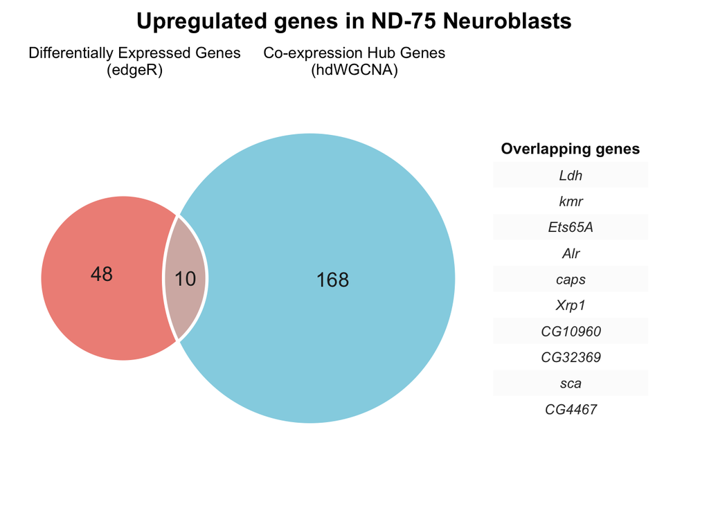

Figure 8: Area-proportional Euler diagram showing overlap between edgeR upregulated DEGs (FDR < 0.05, log2FC ≥ 1) and hdWGCNA ND75-KD-associated module genes (kME ≥ 0.35). Circle areas are proportional to set sizes. Overlap genes are listed on the right, ranked by composite evidence score.

```r
library(eulerr)
library(dplyr)
library(ggplot2)
library(gridExtra)
library(cowplot)

# Define sets and calculate overlap
edger_genes <- edgeR_up_genes

wgcna_genes_filtered <- nb_modules %>%
    filter(module %in% hdWGCNA_up_mods) %>%
    rowwise() %>%
    filter(get(paste0("kME_", module)) >= 0.35) %>%
    ungroup() %>%
    filter(!grepl(exclude_regex, gene_name, ignore.case = TRUE)) %>%
    pull(gene_name)

overlap_genes <- intersect(edger_genes, wgcna_genes_filtered)

# Order overlap genes by evidence score
ordered_overlap_genes <- core_master_stats %>%
    filter(gene %in% overlap_genes) %>%
    arrange(desc(evidence_score)) %>%
    pull(gene)

# Catch any genes missing from the stats dataframe
missing_genes <- setdiff(overlap_genes, ordered_overlap_genes)
ordered_overlap_genes <- c(ordered_overlap_genes, missing_genes)

# Create Euler fit and plot object
venn_fit <- euler(c(
    "edgeR" = length(setdiff(edger_genes, wgcna_genes_filtered)),
    "hdWGCNA" = length(setdiff(wgcna_genes_filtered, edger_genes)),
    "edgeR&hdWGCNA" = length(overlap_genes)
))

euler_plot <- plot(
    venn_fit,
    labels = FALSE,
    quantities = list(cex = 1.2, col = "#222222", fontface = 1L), # 1L for plain font
    fills = list(fill = c("#E64B35", "#4DBBD5"), alpha = 0.65),
    edges = list(lwd = 3, col = "white"),
    margins = unit(c(0, 0, 0, 0), "pt")
)

# Prepare Table Grob
col_name <- paste0("Overlapping genes")
gene_df <- data.frame(ordered_overlap_genes, check.names = FALSE)
colnames(gene_df) <- col_name

# Ensure ttheme_latex is defined with plain headers and no borders
ttheme_latex <- ttheme_minimal(
  core = list(
    fg_params = list(fontface = 3L, fontsize = 10, col = "#333333"),
    bg_params = list(fill = c("#fcfcfc", "#ffffff"))
  ),
  colhead = list(
    fg_params = list(fontface = 2L, fontsize = 11, col = "#111111"),
    bg_params = list(col = NA, fill = "white", lwd = 0)
  )
)

table_grob <- tableGrob(gene_df, theme = ttheme_latex, rows = NULL)

# Assemble the final figure on a single canvas
# Coordinate system is 0 to 1
venn_plot <- ggdraw() +
  # Place Euler Circles: width=0.6 makes them smaller, x=0.05 shoves them left
  draw_plot(euler_plot, x = 0.05, y = 0.05, width = 0.6, height = 0.8) +

  # Place Table: x=0.68 brings it very close to the blue circle
  draw_grob(table_grob, x = 0.68, y = 0.1, width = 0.25, height = 0.7) +

  # Symmetric Labels (Plain font via fontface = 1L)
  # Left Label: Shifted to 0.19 for better spacing
  draw_text("Differentially Expressed Genes\n(edgeR)",
            x = 0.19, y = 0.88, color = "black", size = 11, lineheight = 0.9, fontface = 1L) +

  # Right Label: Updated to 'Co-expression Hub Genes' and centered over blue circle
  draw_text("Co-expression Hub Genes\n(hdWGCNA)",
            x = 0.50, y = 0.88, color = "black", size = 11, lineheight = 0.9, fontface = 1L) +

  # Centered Title
  draw_label("Upregulated genes in ND-75 Neuroblasts",
             x = 0.5, y = 0.96, fontface = "bold", size = 16)

# Render and Save
ggsave(
  filename = here(output_dir, "Venn_edgeR_hdWGCNA_Overlap.pdf"),
  plot = venn_plot,
  device = cairo_pdf,
  width = 10, height = 6
)

# Save PNG (Raster)
# Using ragg::agg_png directly ensures high-quality anti-aliasing
# without the 'type' warning
ggsave(
  filename = here(output_dir, "Venn_edgeR_hdWGCNA_Overlap.png"),
  plot = venn_plot,
  device = ragg::agg_png,
  width = 10, height = 6,
  dpi = 300,
  bg = "white"
)

venn_plot
```

### Integrated core: upregulated in edgeR, hdWGCNA and SCENIC

**Integrated triple-positive core table**

```r
div(
  style = "margin-top: 40px; font-family: sans-serif;",
  reactable(
    core_master_stats,
    pagination = FALSE,
    highlight = TRUE,
    compact = TRUE,
    bordered = TRUE,
    columns = list(
      gene = colDef(
        name = "Gene",
        html = TRUE,
        align = "left",
        cell = function(value, index) {
          fbid <- core_master_stats$fb_id[index]
          if(!is.na(fbid)) make_flybase_link(fbid, value) else value
        },
        style = list(fontStyle = "italic")
      ),
      fb_id = colDef(show = FALSE),
      edgeR_logFC = colDef(name = "log2FC", format = colFormat(digits = 2)),
      edgeR_FDR = colDef(
        name = "FDR",
        cell = function(value) formatC(value, format = "e", digits = 2) # 3 sig digits
      ),
      kME_value = colDef(name = "kME", format = colFormat(digits = 3)),
      TFs = colDef(
        name = "Upstream Regulators",
        html = TRUE,
        align = "left",
        style = list(fontSize = "0.85em"),
        cell = function(value, index) {
          if (is.na(value) || value == "") return("")
          tfs_list    <- strsplit(value, ", ")[[1]]
          coupled_str <- core_master_stats$ldh_coupled_TFs[index]
          coupled_set <- if (!is.na(coupled_str) && coupled_str != "")
                             strsplit(coupled_str, ", ")[[1]] else character(0)
          n_total   <- length(tfs_list)
          n_coupled <- length(coupled_set)
          # Count badge: "3 TFs (2 Ldh★)"
          badge <- paste0(
            '<span style="font-weight:bold;color:#555;font-size:0.95em">',
            n_total, ' TF', if (n_total != 1) "s" else "",
            if (n_coupled > 0) paste0(
              ' <span style="color:#67001F">(', n_coupled, ' Ldh&#9733;)</span>'
            ) else "",
            '</span><br>'
          )
          links <- sapply(tfs_list, function(tf) {
            match_row <- global_annotation_map[global_annotation_map$gene == tf, ]
            link_txt  <- if (nrow(match_row) > 0 && !is.na(match_row$fb_id[1]))
                             as.character(make_flybase_link(match_row$fb_id[1], tf))
                         else tf
            if (tf %in% coupled_set)
                paste0('<span style="color:#67001F;font-weight:bold">', link_txt, ' &#9733;</span>')
            else link_txt
          })
          htmltools::HTML(paste0(badge, paste(links, collapse = ", ")))
        }
      ),
      # Hide redundant columns now encoded in the Upstream Regulators cell
      TF_count          = colDef(show = FALSE),
      ldh_coupled_TFs   = colDef(show = FALSE),
      n_ldh_coupled_tfs = colDef(show = FALSE),
      # Hide intermediate scoring columns not relevant to the reader
      mean_tf_rb_r         = colDef(show = FALSE),
      max_tf_ldh_delta_rho = colDef(show = FALSE),
      module_correlation   = colDef(show = FALSE)
    )
  )
)
```

| Gene | log2FC | FDR | module | kME | Upstream Regulators | evidence_score |
| --- | --- | --- | --- | --- | --- | --- |
| Ldh | 3.20777782038344 | 1.93704646733132e-19 | NB_M9 | 0.785494784175945 | crc, Ets65A, Vsx2, wdn, elB | 82.75 |
| kmr | 2.07588348265417 | 5.51117388406983e-10 | NB_M9 | 0.709189837206749 | crc, Ets65A, E(spl)m3-HLH, Pdp1, stc, da, Myc, usp, CG10979, hang, Snoo, fru, sima, zfh2, Ssrp, CG4360, svp, dwg, Thd1, ewg, Xbp1, ftz-f1, woc, dysf, phol, psq, kay, lola, fs(1)h, MESR4, cwo, mld, sd,… | 60.75 |
| Ets65A | 2.25489980193613 | 4.1485918296854e-08 | NB_M9 | 0.607249059344481 | crc, Pdp1, stc, CG9305, CG10979, hang, Vsx2, fru, sima, ewg, dysf, psq, SoxN, kay, lola, mld, REPTOR, ken, pzg, acj6, ase, BtbVII, Glut4EF, Met, vri, Vsx1, CG13775 | 57.5 |
| Alr | 1.26386790905691 | 3.98430968220047e-05 | NB_M9 | 0.441623180348502 | crc, Ets65A | 54.25 |
| caps | 2.05855284167119 | 0.000475535079439092 | NB_M9 | 0.445223542980763 | crc, Ets65A, E(spl)m3-HLH, Pdp1, cyc, hang, Vsx2, Mrtf, fru, sima, Thd1, woc, psq, Cf2, lola, onecut, crp, wdn, E(bx), REPTOR, ct, cnc, Ptx1, vvl, grh, polybromo, CG10543, bun, CG32767, lilli, MTA1-li… | 39.75 |
| Xrp1 | 1.16279040233412 | 4.56223020347974e-06 | NB_M9 | 0.52301007911102 | Ets65A, E(spl)m3-HLH, Pdp1, da, Usf, CG10979, Aef1, Mrtf, Snoo, fru, sima, zfh2, Mitf, Thd1, ftz-f1, woc, dysf, psq, SoxN, Kr-h1, lola, onecut, CG11247, crol, NFAT, CG6791, cic, CG32767, tsh, chinmo, … | 38.75 |
| CG10960 | 1.6750909399491 | 0.000911223206258655 | NB_M9 | 0.433393518511669 | crc, Ets65A, Pdp1, hang, Snoo, zfh2, Thd1, Xbp1, woc, lola, GATAd, fs(1)h, crp, REPTOR, ct, klu, Abd-B, chinmo, Mef2, CG6272, HGTX, CG15696, vis | 38.25 |
| CG32369 | 1.06050722704002 | 0.000270399109297169 | NB_M9 | 0.502462986292787 | E(spl)m3-HLH, Pdp1, da, Myc, CG9305, Usf, CG10979, hang, fru, sima, Thd1, ewg, Xbp1, dysf, psq, SoxN, kay, lola, fs(1)h, MESR4, Dsp1, wdn, crol, REPTOR, ct, cnc, CG18476, cic, shn, sqz, CG32767, tsh, … | 36.25 |
| sca | 1.63444138766987 | 0.000460211030222648 | NB_M7 | 0.417684301276072 | Usf, rgr, hang, Snoo, fru, sima, Ssrp, CG4360, Mitf, CG1233, lola, fs(1)h, Dsp1, sd, wdn, crol, REPTOR, ct, cnc, NFAT, shn, grh, CG31224, sna, Mnt, run, l(3)neo38, wor, ttk, nub, zf30C, vri | 13.5 |
| CG4467 | 1.18011920250042 | 0.0142680056157565 | NB_M9 | 0.356302052753964 | Pdp1, sima, zfh2, su(Hw), Thd1, psq, fs(1)h, crp, sd, E(bx), CG32767, tsh, chinmo, l(3)neo38, Smox, Met, HGTX, Eip75B, Spps, lov, CG32772, vri, pnt | 1.5 |

### Master regulators of the core

Transcription factors prioritized by their regulatory degree within the triple-positive core, representing functional drivers validated across expression, connectivity and motif enrichment.

**Master-regulator hierarchy table**

```r
div(
  style = "margin-top: 40px; font-family: sans-serif;",
  reactable(
    master_regulators,
    compact = TRUE,
    bordered = TRUE,
    columns = list(
      TFs = colDef(
        name = "Transcription Factor",
        html = TRUE,
        style = list(fontWeight = "bold"),
        cell = function(value) {
          # Clean name to ensure match with annotation map
          tf_clean <- gsub("\\(\\+\\)", "", value)
          match_row <- global_annotation_map[global_annotation_map$gene == tf_clean, ]

          if (nrow(match_row) > 0 && !is.na(match_row$fb_id[1])) {
            make_flybase_link(match_row$fb_id[1], tf_clean)
          } else {
            tf_clean
          }
        }
      ),
      ldh_coupled = colDef(
    name  = "Ldh-Coupled",
    width = 110,
    style = function(value) {
        if (isTRUE(value)) list(color = "#67001F", fontWeight = "bold")
        else list(color = "#bbb")
    },
    cell = function(value) if (isTRUE(value)) "● Ldh" else "—"
),
      target_count = colDef(name = "Degree", width = 100),
      targets = colDef(
        name = "Regulated Core Genes",
        html = TRUE,
        align = "left",
        style = list(fontSize = "0.85em", fontStyle = "italic"),
        cell = function(value) {
          if (is.na(value) || value == "") return("")

          # Split comma-separated targets
          gene_list <- strsplit(value, ", ")[[1]]

          # Map each gene to its FlyBase link
          links <- sapply(gene_list, function(g) {
            match_row <- global_annotation_map[global_annotation_map$gene == g, ]
            if (nrow(match_row) > 0 && !is.na(match_row$fb_id[1])) {
              as.character(make_flybase_link(match_row$fb_id[1], g))
            } else {
              g
            }
          })

          htmltools::HTML(paste(links, collapse = ", "))
        }
      )
    )
  )
)
```

| Transcription Factor | Degree | Regulated Core Genes | Ldh-Coupled |
| --- | --- | --- | --- |
| Pdp1 | 7 | CG10960, CG32369, CG4467, Ets65A, Xrp1, caps, kmr | True |
| lola | 7 | CG10960, CG32369, Ets65A, Xrp1, caps, kmr, sca | False |
| sima | 7 | CG32369, CG4467, Ets65A, Xrp1, caps, kmr, sca | False |
| Ets65A | 6 | Alr, CG10960, Ldh, Xrp1, caps, kmr | True |
| Thd1 | 6 | CG10960, CG32369, CG4467, Xrp1, caps, kmr | False |
| crc | 6 | Alr, CG10960, Ets65A, Ldh, caps, kmr | True |
| fru | 6 | CG32369, Ets65A, Xrp1, caps, kmr, sca | False |
| hang | 6 | CG10960, CG32369, Ets65A, caps, kmr, sca | False |
| psq | 6 | CG32369, CG4467, Ets65A, Xrp1, caps, kmr | False |
| CG32767 | 5 | CG32369, CG4467, Xrp1, caps, kmr | False |

[output cut: 131 more lines]

### Core gene multi-evidence ranking

**Core-gene evidence-score table**

```r
score_table_data <- core_master_stats %>%
    dplyr::select(
        gene, fb_id, evidence_score,
        edgeR_logFC, kME_value,
        mean_tf_rb_r, n_ldh_coupled_tfs
    ) %>%
    mutate(
        evidence_score = round(evidence_score, 3),
        edgeR_logFC    = signif(edgeR_logFC, 3),
        kME_value      = signif(kME_value, 3),
        mean_tf_rb_r   = signif(mean_tf_rb_r, 3)
    )

max_score <- max(abs(score_table_data$evidence_score), na.rm = TRUE)

div(
    style = "margin-top: 40px; font-family: sans-serif;",
    reactable(
        score_table_data,
        pagination        = FALSE,
        highlight         = TRUE,
        compact           = TRUE,
        bordered          = TRUE,
        defaultSortOrder  = "desc",
        defaultSorted     = list(evidence_score = "desc"),
        defaultColDef     = colDef(align = "center"),
        columns = list(
            gene = flybase_column(score_table_data),
            fb_id = colDef(show = FALSE),
            evidence_score = colDef(
                name = "Evidence Score",
                cell = function(value) {
                    width <- paste0((abs(value) / max_score) * 100, "%")
                    color <- if (value >= 0) "#B2182B" else "#2166AC"
                    bar_container <- div(
                        style = list(display = "flex", alignItems = "center",
                                     width = "120px", height = "18px"),
                        div(style = list(width = "50%", display = "flex",
                                         justifyContent = "flex-end"),
                            if (value < 0)
                                div(style = list(background = color, width = width,
                                                 height = "10px", borderRadius = "2px"))),
                        div(style = list(width = "1px", height = "100%",
                                         background = "#ccc", margin = "0 2px")),
                        div(style = list(width = "50%", display = "flex",
                                         justifyContent = "flex-start"),
                            if (value >= 0)
                                div(style = list(background = color, width = width,
                                                 height = "10px", borderRadius = "2px")))
                    )
                    div(style = list(display = "flex", alignItems = "center"),
                        span(style = list(width = "45px", textAlign = "right",
                                          marginRight = "10px"), value),
                        bar_container)
                }
            ),
            edgeR_logFC       = colDef(name = "log2FC"),
            kME_value         = colDef(name = "kME"),
            mean_tf_rb_r      = colDef(name = "Mean TF rb-r"),
            n_ldh_coupled_tfs = colDef(name = "Ldh-Coupled TFs")
        )
    )
)
```

| Gene | Evidence Score | log2FC | kME | Mean TF rb-r | Ldh-Coupled TFs |
| --- | --- | --- | --- | --- | --- |
| Ldh | 82.75 | 3.21 | 0.785 | 0.45 | 4 |
| kmr | 60.75 | 2.08 | 0.709 | 0.394 | 9 |
| Ets65A | 57.5 | 2.25 | 0.607 | 0.398 | 7 |
| Alr | 54.25 | 1.26 | 0.442 | 0.554 | 2 |
| caps | 39.75 | 2.06 | 0.445 | 0.376 | 7 |
| Xrp1 | 38.75 | 1.16 | 0.523 | 0.389 | 6 |
| CG10960 | 38.25 | 1.68 | 0.433 | 0.404 | 4 |
| CG32369 | 36.25 | 1.06 | 0.502 | 0.389 | 5 |
| sca | 13.5 | 1.63 | 0.418 | 0.393 | 2 |
| CG4467 | 1.5 | 1.18 | 0.356 | 0.369 | 2 |